# Deep Learning - Project 2 - Convolutional Neural Networks - 2023/24

### Conclusion

The experiment indicates that a `0.4` dropout rate is most beneficial for our CNN model, striking an optimal balance between accuracy, precision, recall, and F1-score while also maintaining a reasonable training duration. This finding is crucial for enhancing model reliability and efficiency in practical applications.

```
Evaluating best_model_dropout_0.4
```

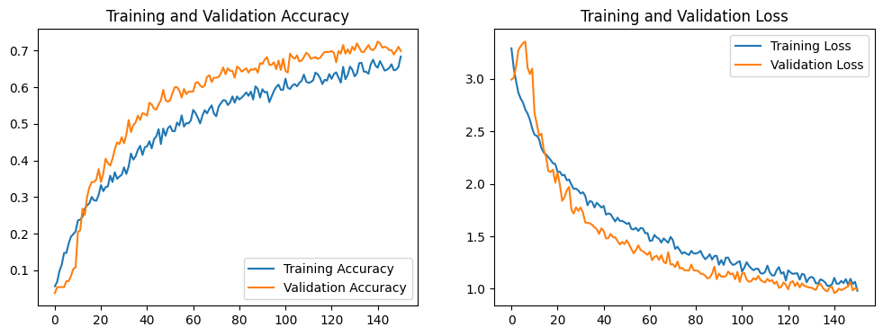

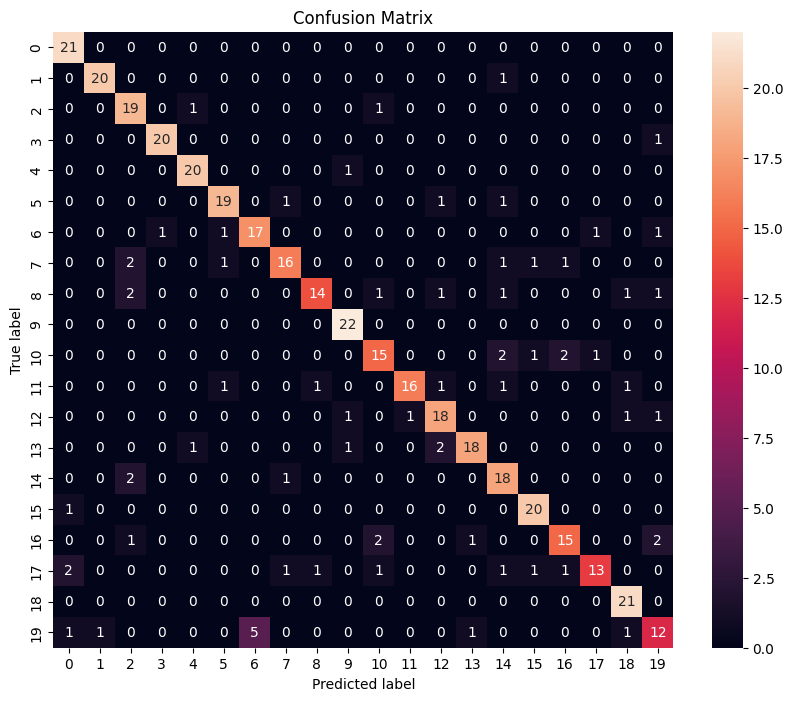

```
[[21  0  0  0  0  0  0  0  0  0  0  0  0  0  0  0  0  0  0  0]
 [ 0 20  0  0  0  0  0  0  0  0  0  0  0  0  1  0  0  0  0  0]
 [ 0  0 19  0  1  0  0  0  0  0  1  0  0  0  0  0  0  0  0  0]
 [ 0  0  0 20  0  0  0  0  0  0  0  0  0  0  0  0  0  0  0  1]
 [ 0  0  0  0 20  0  0  0  0  1  0  0  0  0  0  0  0  0  0  0]
 [ 0  0  0  0  0 19  0  1  0  0  0  0  1  0  1  0  0  0  0  0]
 [ 0  0  0  1  0  1 17  0  0  0  0  0  0  0  0  0  0  1  0  1]
 [ 0  0  2  0  0  1  0 16  0  0  0  0  0  0  1  1  1  0  0  0]
 [ 0  0  2  0  0  0  0  0 14  0  1  0  1  0  1  0  0  0  1  1]
 [ 0  0  0  0  0  0  0  0  0 22  0  0  0  0  0  0  0  0  0  0]
 [ 0  0  0  0  0  0  0  0  0  0 15  0  0  0  2  1  2  1  0  0]
 [ 0  0  0  0  0  1  0  0  1  0  0 16  1  0  1  0  0  0  1  0]
 [ 0  0  0  0  0  0  0  0  0  1  0  1 18  0  0  0  0  0  1  1]
 [ 0  0  0  0  1  0  0  0  0  1  0  0  2 18  0  0  0  0  0  0]
 [ 0  0  2  0  0  0  0  1  0  0  0  0  0  0 18  0  0  0  0  0]
 [ 1  0  0  0  0  0  0  0  0  0  0  0  0  0  0 20  0  0  0  0]
 [ 0  0  1  0  0  0  0  0  0  0  2  0  0  1  0  0 15  0  0  2]
 [ 2  0  0  0  0  0  0  1  1  0  1  0  0  0  1  1  1 13  0  0]
 [ 0  0  0  0  0  0  0  0  0  0  0  0  0  0  0  0  0  0 21  0]
 [ 1  1  0  0  0  0  5  0  0  0  0  0  0  1  0  0  0  0  1 12]]
              precision    recall  f1-score     support
Faces          0.840000  1.000000  0.913043   21.000000
Faces_easy     0.952381  0.952381  0.952381   21.000000
Leopards       0.730769  0.904762  0.808511   21.000000
Motorbikes     0.952381  0.952381  0.952381   21.000000
airplanes      0.909091  0.952381  0.930233   21.000000
bonsai         0.863636  0.863636  0.863636   22.000000
brain          0.772727  0.809524  0.790698   21.000000
buddha         0.842105  0.727273  0.780488   22.000000
butterfly      0.875000  0.666667  0.756757   21.000000
car_side       0.880000  1.000000  0.936170   22.000000
chandelier     0.750000  0.714286  0.731707   21.000000
grand_piano    0.941176  0.761905  0.842105   21.000000
hawksbill      0.782609  0.818182  0.800000   22.000000
helicopter     0.900000  0.818182  0.857143   22.000000
kangaroo       0.692308  0.857143  0.765957   21.000000
ketch          0.869565  0.952381  0.909091   21.000000
menorah        0.789474  0.714286  0.750000   21.000000
starfish       0.866667  0.619048  0.722222   21.000000
trilobite      0.840000  1.000000  0.913043   21.000000
watch          0.666667  0.571429  0.615385   21.000000
accuracy       0.832941  0.832941  0.832941    0.832941
macro avg      0.835828  0.832792  0.829548  425.000000
weighted avg   0.836038  0.832941  0.829759  425.000000
```

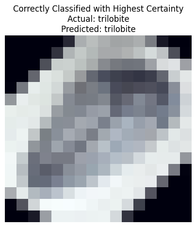

```
Acutal: trilobite
Predicted: trilobite
Probability of brain: 0.000057
Probability of butterfly: 0.000008
Probability of hawksbill: 0.000006
Probability of trilobite: 0.999928
```

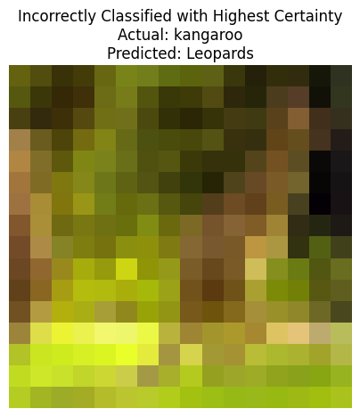

```
Acutal: kangaroo
Predicted: Leopards
Probability of Leopards: 0.973412
Probability of airplanes: 0.000005
Probability of bonsai: 0.000164
Probability of brain: 0.000012
Probability of buddha: 0.004893
Probability of butterfly: 0.000510
Probability of chandelier: 0.001676
Probability of grand_piano: 0.000001
Probability of hawksbill: 0.000100
Probability of helicopter: 0.000131
Probability of kangaroo: 0.018044
Probability of menorah: 0.000669
Probability of starfish: 0.000100
Probability of trilobite: 0.000002
Probability of watch: 0.000279
Evaluating best_model_dropout_0.5
```

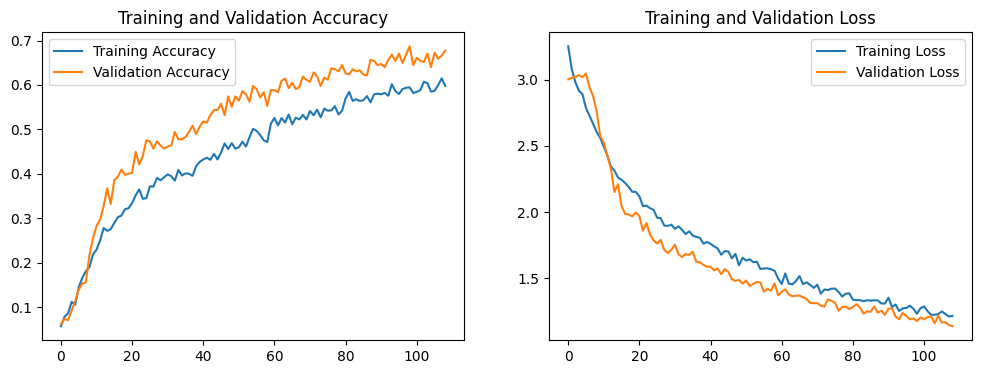

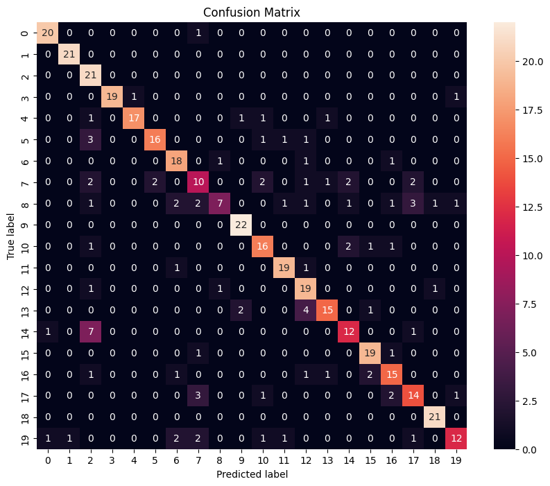

```
[[20  0  0  0  0  0  0  1  0  0  0  0  0  0  0  0  0  0  0  0]
 [ 0 21  0  0  0  0  0  0  0  0  0  0  0  0  0  0  0  0  0  0]
 [ 0  0 21  0  0  0  0  0  0  0  0  0  0  0  0  0  0  0  0  0]
 [ 0  0  0 19  1  0  0  0  0  0  0  0  0  0  0  0  0  0  0  1]
 [ 0  0  1  0 17  0  0  0  0  1  1  0  0  1  0  0  0  0  0  0]
 [ 0  0  3  0  0 16  0  0  0  0  1  1  1  0  0  0  0  0  0  0]
 [ 0  0  0  0  0  0 18  0  1  0  0  0  1  0  0  0  1  0  0  0]
 [ 0  0  2  0  0  2  0 10  0  0  2  0  1  1  2  0  0  2  0  0]
 [ 0  0  1  0  0  0  2  2  7  0  0  1  1  0  1  0  1  3  1  1]
 [ 0  0  0  0  0  0  0  0  0 22  0  0  0  0  0  0  0  0  0  0]
 [ 0  0  1  0  0  0  0  0  0  0 16  0  0  0  2  1  1  0  0  0]
 [ 0  0  0  0  0  0  1  0  0  0  0 19  1  0  0  0  0  0  0  0]
 [ 0  0  1  0  0  0  0  0  1  0  0  0 19  0  0  0  0  0  1  0]
 [ 0  0  0  0  0  0  0  0  0  2  0  0  4 15  0  1  0  0  0  0]
 [ 1  0  7  0  0  0  0  0  0  0  0  0  0  0 12  0  0  1  0  0]
 [ 0  0  0  0  0  0  0  1  0  0  0  0  0  0  0 19  1  0  0  0]
 [ 0  0  1  0  0  0  1  0  0  0  0  0  1  1  0  2 15  0  0  0]
 [ 0  0  0  0  0  0  0  3  0  0  1  0  0  0  0  0  2 14  0  1]
 [ 0  0  0  0  0  0  0  0  0  0  0  0  0  0  0  0  0  0 21  0]
 [ 1  1  0  0  0  0  2  2  0  0  1  1  0  0  0  0  0  1  0 12]]
              precision    recall  f1-score     support
Faces          0.909091  0.952381  0.930233   21.000000
Faces_easy     0.954545  1.000000  0.976744   21.000000
Leopards       0.552632  1.000000  0.711864   21.000000
Motorbikes     1.000000  0.904762  0.950000   21.000000
airplanes      0.944444  0.809524  0.871795   21.000000
bonsai         0.888889  0.727273  0.800000   22.000000
brain          0.750000  0.857143  0.800000   21.000000
buddha         0.526316  0.454545  0.487805   22.000000
butterfly      0.777778  0.333333  0.466667   21.000000
car_side       0.880000  1.000000  0.936170   22.000000
chandelier     0.727273  0.761905  0.744186   21.000000
grand_piano    0.863636  0.904762  0.883721   21.000000
hawksbill      0.655172  0.863636  0.745098   22.000000
helicopter     0.833333  0.681818  0.750000   22.000000
kangaroo       0.705882  0.571429  0.631579   21.000000
ketch          0.826087  0.904762  0.863636   21.000000
menorah        0.714286  0.714286  0.714286   21.000000
starfish       0.666667  0.666667  0.666667   21.000000
trilobite      0.913043  1.000000  0.954545   21.000000
watch          0.800000  0.571429  0.666667   21.000000
accuracy       0.783529  0.783529  0.783529    0.783529
macro avg      0.794454  0.783983  0.777583  425.000000
weighted avg   0.794010  0.783529  0.777186  425.000000
```

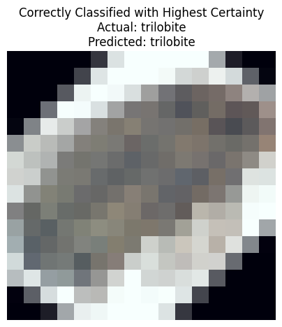

```
Acutal: trilobite
Predicted: trilobite
Probability of brain: 0.000055
Probability of butterfly: 0.000103
Probability of grand_piano: 0.000009
Probability of hawksbill: 0.000011
Probability of trilobite: 0.999821
```

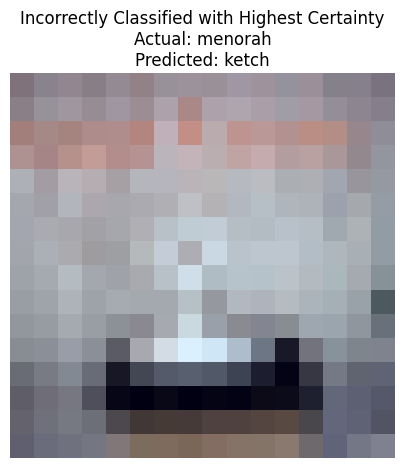

```
Acutal: menorah
Predicted: ketch
Probability of Faces: 0.000124
Probability of Faces_easy: 0.000002
Probability of Leopards: 0.000008
Probability of Motorbikes: 0.000035
Probability of airplanes: 0.000330
Probability of bonsai: 0.000008
Probability of brain: 0.000132
Probability of buddha: 0.002058
Probability of butterfly: 0.000343
Probability of chandelier: 0.003768
Probability of grand_piano: 0.000002
Probability of hawksbill: 0.000542
Probability of helicopter: 0.004252
Probability of kangaroo: 0.000249
Probability of ketch: 0.983479
Probability of menorah: 0.003257
Probability of starfish: 0.001398
Probability of watch: 0.000013
```

```python
best_model_names = ['best_model_dropout_0.4', 'best_model_dropout_0.5']

for model_name in best_model_names:
    print(f"Evaluating {model_name}")
    model, history, X_test_std, y_test, lb = load_model_and_history(path_name, model_name)
    df_report = plot_and_evaluate_model(model, history, X_test_std, y_test, lb)
    print(df_report)
    show_predictions(model, X_test_std, y_test, lb, correctly_classified_images=1, incorrectly_classified_images=1)
```

## Comparative Analysis of Dropout Models

### Overview

We conducted an experiment to compare the performance of two Convolutional Neural Network models with different dropout rates: `0.4` and `0.5`. The comparison is based on various parameters including predictive ability, overfitting/underfitting impact, training duration, model complexity, learning curve, and overall profitability of the modifications.

### Predictive Ability

- **Model with Dropout Rate of 0.4**:
  - Achieved an accuracy of approximately 83.29%.
  - Showed high precision in categories like 'Faces','Motorbikes', and 'Airplanes'.
- **Model with Dropout Rate of 0.5**:
  - Recorded a lower accuracy of around 78.35%.
  - Demonstrated proficiency in 'Faces_easy', 'Motorbikes', and 'Trilobite', but underperformed in 'Buddha' and 'Butterfly'.

### Training Duration and Model Complexity

- Dropout 0.4: Longer training time (78.37 seconds) which could be attributed to the slightly more complex nature of the model.
- Dropout 0.5: Shorter training duration (56.77 seconds), indicating a less complex model, potentially leading to quicker convergence but at the cost of accuracy.

### Assumptions and Potential Adjustments

- The dropout rate of 0.4 seems to be the optimal choice, providing a good balance between preventing overfitting and maintaining high accuracy.
- For further improvements, experimenting with dropout rates slightly below or above 0.4 could be considered to fine-tune the balance.

### Conclusion

Based on the analysis, the model with a dropout rate of 0.4 emerges as the best option. It offers a superior balance between accuracy, learning stability, and overfitting mitigation, making it a more effective choice for this specific dataset and CNN architecture.

```
Training model with None regularizer
Loading existing model...
Model model_regularizer_None_0 accuracy: 0.6541176470588236
Loading existing model...
Model model_regularizer_None_1 accuracy: 0.7505882352941177
Loading existing model...
Model model_regularizer_None_2 accuracy: 0.6494117647058824
Loading existing model...
Model model_regularizer_None_3 accuracy: 0.5858823529411765
Loading existing model...
Model model_regularizer_None_4 accuracy: 0.7647058823529411
Model best_model_regularizer_None saved successfully.
Data for best_model_regularizer_None saved successfully.
Saved best model model_regularizer_None_4 with accuracy: 0.7647058823529411

Training model with l1 regularizer
Loading existing model...
Model model_regularizer_l1_0 accuracy: 0.6705882352941176
Loading existing model...
Model model_regularizer_l1_1 accuracy: 0.8164705882352942
Loading existing model...
Model model_regularizer_l1_2 accuracy: 0.7082352941176471
Loading existing model...
Model model_regularizer_l1_3 accuracy: 0.7811764705882352
Loading existing model...
Model model_regularizer_l1_4 accuracy: 0.7552941176470588
Model best_model_regularizer_l1 saved successfully.
Data for best_model_regularizer_l1 saved successfully.
Saved best model model_regularizer_l1_1 with accuracy: 0.8164705882352942

Training model with l2 regularizer
Loading existing model...
Model model_regularizer_l2_0 accuracy: 0.6988235294117647
Loading existing model...
Model model_regularizer_l2_1 accuracy: 0.7082352941176471
Loading existing model...
Model model_regularizer_l2_2 accuracy: 0.8047058823529412
Loading existing model...
Model model_regularizer_l2_3 accuracy: 0.7341176470588235
Loading existing model...
Model model_regularizer_l2_4 accuracy: 0.7129411764705882
Model best_model_regularizer_l2 saved successfully.
Data for best_model_regularizer_l2 saved successfully.
Saved best model model_regularizer_l2_2 with accuracy: 0.8047058823529412

Training model with l1_l2 regularizer
Loading existing model...
Model model_regularizer_l1_l2_0 accuracy: 0.7435294117647059
Loading existing model...
Model model_regularizer_l1_l2_1 accuracy: 0.7388235294117647
Loading existing model...
Model model_regularizer_l1_l2_2 accuracy: 0.7388235294117647
Loading existing model...
Model model_regularizer_l1_l2_3 accuracy: 0.8
Loading existing model...
Model model_regularizer_l1_l2_4 accuracy: 0.7623529411764706
Model best_model_regularizer_l1_l2 saved successfully.
Data for best_model_regularizer_l1_l2 saved successfully.
Saved best model model_regularizer_l1_l2_3 with accuracy: 0.8
```

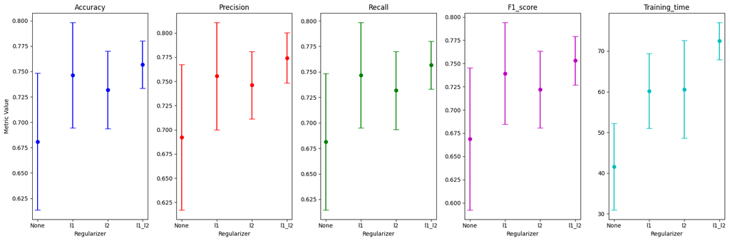

```
Evaluation metrics with standard deviation: {'regularizer': ['None', 'l1', 'l2', 'l1_l2'], 'accuracy': {'mean': [0.6809411764705883, 0.7463529411764707, 0.731764705882353, 0.7567058823529412], 'std': [0.06725626249124057, 0.05177326132508262, 0.03825972070433476, 0.023321433775743784]}, 'precision':…
```

```python
regularizers = ["None", 'l1', 'l2', 'l1_l2']

path_name = "models_regularizers"

evaluation_metrics = {
    'regularizer': [],
    'accuracy': {'mean': [], 'std': []},
    'precision': {'mean': [], 'std': []},
    'recall': {'mean': [], 'std': []},
    'f1_score': {'mean': [], 'std': []},
    'training_time': {'mean': [], 'std': []}
}

images, labels, one_hot_labels, lb = load_images_from_folder(data_folder, target_size=(16, 16))

for regularizer in regularizers:
    print(f"\nTraining model with {regularizer} regularizer")
    accuracies, precisions, recalls, f1_scores, training_times = [], [], [], [], []

    best_model = None
    best_model_name = None
    best_accuracy = 0
    best_history = None
    best_training_time = None

    for i in range(5):
        X_train_std, X_test_std, y_train, y_test, lb = prepare_train_test_sets(images, labels, test_size=0.25, random_state=42)
        model_name = f"model_regularizer_{regularizer}_{i}"
        model, history, training_time, num_params, X_test, y_test, lb = create_and_train_model(model, X_train_std, y_train, X_test_std, y_test, lb, X_train_std.shape[1:], y_train.shape[1], path_name, model_name, dropout_rate=0.4, use_regularizer=regularizer)

        y_pred = model.predict(X_test)
        y_pred_classes = np.argmax(y_pred, axis=1)
        y_true = np.argmax(y_test, axis=1)
        report = classification_report(y_true, y_pred_classes, output_dict=True, zero_division=1)

        accuracies.append(report['accuracy'])
        precisions.append(report['macro avg']['precision'])
        recalls.append(report['macro avg']['recall'])
        f1_scores.append(report['macro avg']['f1-score'])
        training_times.append(training_time)

        current_accuracy = report['accuracy']
        if current_accuracy > best_accuracy:
            best_accuracy = current_accuracy
            best_model = model
            best_model_name = model_name
            best_history = history
            best_training_time = training_time

        print(f"Model {model_name} accuracy: {current_accuracy}")

    evaluation_metrics['regularizer'].append(regularizer)
    evaluation_metrics['accuracy']['mean'].append(np.mean(accuracies))
    evaluation_metrics['accuracy']['std'].append(np.std(accuracies))
    evaluation_metrics['precision']['mean'].append(np.mean(precisions))
    evaluation_metrics['precision']['std'].append(np.std(precisions))
    evaluation_metrics['recall']['mean'].append(np.mean(recalls))
    evaluation_metrics['recall']['std'].append(np.std(recalls))
    evaluation_metrics['f1_score']['mean'].append(np.mean(f1_scores))
    evaluation_metrics['f1_score']['std'].append(np.std(f1_scores))
    evaluation_metrics['training_time']['mean'].append(np.mean(training_times))
    evaluation_metrics['training_time']['std'].append(np.std(training_times))

    if best_model:
        save_model_and_data(best_model, best_history, best_training_time, num_params, path_name, f"best_model_regularizer_{regularizer}", X_test, y_test, lb)
        print(f"Saved best model {best_model_name} with accuracy: {best_accuracy}")

plt.figure(figsize=(18, 6))

def plot_with_error(metric_name, subplot_index, color):
    plt.subplot(1, 5, subplot_index)
    plt.errorbar(evaluation_metrics['regularizer'],
                    evaluation_metrics[metric_name]['mean'],
                    yerr=evaluation_metrics[metric_name]['std'],
                    fmt='o', ecolor=color, capsize=5, color=color)
    plt.title(metric_name.capitalize())
    plt.xlabel('Regularizer')
    if subplot_index == 1:
        plt.ylabel('Metric Value')

plot_with_error('accuracy', 1, 'b')
plot_with_error('precision', 2, 'r')
plot_with_error('recall', 3, 'g')
plot_with_error('f1_score', 4, 'm')
plot_with_error('training_time', 5, 'c')

plt.tight_layout()
plt.show()

print("Evaluation metrics with standard deviation:", evaluation_metrics)
```

## Regularization Experiment Summary

### Objective

The experiment aimed to evaluate the impact of different regularization methods (`None`, `l1`, `l2`, `l1_l2`) on a convolutional neural network's performance. Regularization techniques are critical in machine learning to prevent overfitting and improve model generalization.

### Models Trained

- Models without regularization (`None`)
- Models with L1 regularization (`l1`)
- Models with L2 regularization (`l2`)
- Models with combined L1 and L2 regularization (`l1_l2`)

Each model was trained five times with different seeds for consistency in the results.

### Evaluation Metrics

- **Accuracy**: Measures the proportion of correctly classified instances.
- **Precision**: Measures the proportion of positive identifications that were actually correct.
- **Recall**: Measures the proportion of actual positives that were correctly identified.
- **F1-Score**: Harmonic mean of precision and recall.
- **Training Time**: Time taken to train each model.

### Conclusions and Recommendations

- **Effectiveness of Regularization**:
  - Regularization techniques, particularly the combined l1_l2 method, significantly improved the model's predictive ability, precision, recall, and F1-score.
  - The increase in training time for regularized models is justifiable given the improvement in performance metrics.
- **Selection of Regularization Technique**:
  - The l1_l2 regularized model is recommended for scenarios prioritizing high accuracy and generalization.
  - For faster training with slightly lower, but still competitive performance, the l1 regularized model is a suitable choice.
- **Potential for Overfitting**:
  - Models without regularization (None) showed the lowest performance metrics, indicating a higher risk of overfitting compared to regularized models.

### Future Work

- **Testing on Diverse Datasets**:
  - Applying these models to a variety of datasets can further validate the effectiveness of each regularization technique.
- **Hyperparameter Tuning**:
  - Fine-tuning the regularization parameters could yield even better results and should be considered in future experiments.
- **Computational Constraints**:
  - For environments with strict computational time constraints, balancing regularization techniques with training time will be crucial.

```
Evaluating best_model_regularizer_l1
```

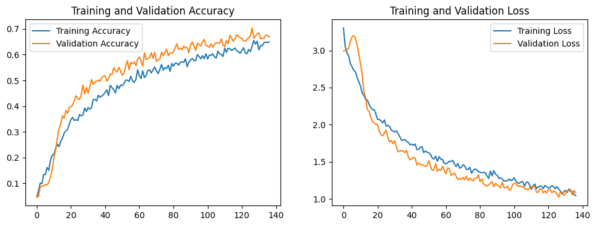

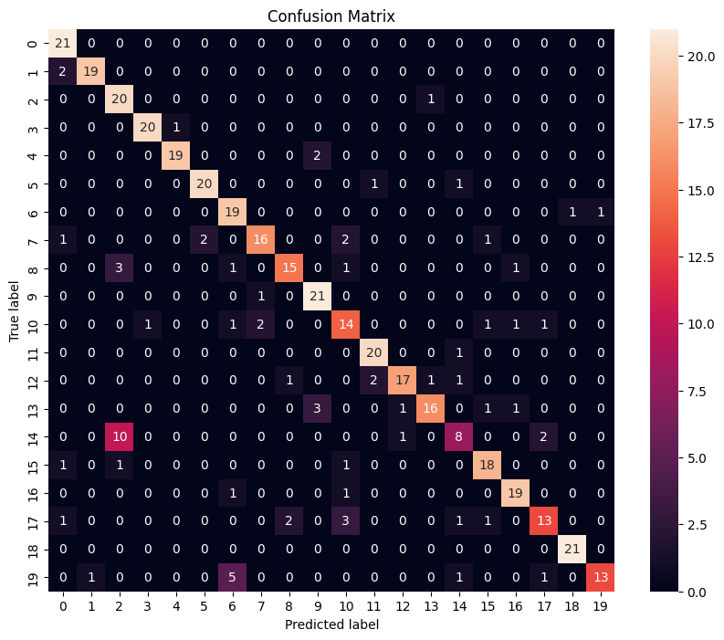

```
[[21  0  0  0  0  0  0  0  0  0  0  0  0  0  0  0  0  0  0  0]
 [ 2 19  0  0  0  0  0  0  0  0  0  0  0  0  0  0  0  0  0  0]
 [ 0  0 20  0  0  0  0  0  0  0  0  0  0  1  0  0  0  0  0  0]
 [ 0  0  0 20  1  0  0  0  0  0  0  0  0  0  0  0  0  0  0  0]
 [ 0  0  0  0 19  0  0  0  0  2  0  0  0  0  0  0  0  0  0  0]
 [ 0  0  0  0  0 20  0  0  0  0  0  1  0  0  1  0  0  0  0  0]
 [ 0  0  0  0  0  0 19  0  0  0  0  0  0  0  0  0  0  0  1  1]
 [ 1  0  0  0  0  2  0 16  0  0  2  0  0  0  0  1  0  0  0  0]
 [ 0  0  3  0  0  0  1  0 15  0  1  0  0  0  0  0  1  0  0  0]
 [ 0  0  0  0  0  0  0  1  0 21  0  0  0  0  0  0  0  0  0  0]
 [ 0  0  0  1  0  0  1  2  0  0 14  0  0  0  0  1  1  1  0  0]
 [ 0  0  0  0  0  0  0  0  0  0  0 20  0  0  1  0  0  0  0  0]
 [ 0  0  0  0  0  0  0  0  1  0  0  2 17  1  1  0  0  0  0  0]
 [ 0  0  0  0  0  0  0  0  0  3  0  0  1 16  0  1  1  0  0  0]
 [ 0  0 10  0  0  0  0  0  0  0  0  0  1  0  8  0  0  2  0  0]
 [ 1  0  1  0  0  0  0  0  0  0  1  0  0  0  0 18  0  0  0  0]
 [ 0  0  0  0  0  0  1  0  0  0  1  0  0  0  0  0 19  0  0  0]
 [ 1  0  0  0  0  0  0  0  2  0  3  0  0  0  1  1  0 13  0  0]
 [ 0  0  0  0  0  0  0  0  0  0  0  0  0  0  0  0  0  0 21  0]
 [ 0  1  0  0  0  0  5  0  0  0  0  0  0  0  1  0  0  1  0 13]]
              precision    recall  f1-score     support
Faces          0.807692  1.000000  0.893617   21.000000
Faces_easy     0.950000  0.904762  0.926829   21.000000
Leopards       0.588235  0.952381  0.727273   21.000000
Motorbikes     0.952381  0.952381  0.952381   21.000000
airplanes      0.950000  0.904762  0.926829   21.000000
bonsai         0.909091  0.909091  0.909091   22.000000
brain          0.703704  0.904762  0.791667   21.000000
buddha         0.842105  0.727273  0.780488   22.000000
butterfly      0.833333  0.714286  0.769231   21.000000
car_side       0.807692  0.954545  0.875000   22.000000
chandelier     0.636364  0.666667  0.651163   21.000000
grand_piano    0.869565  0.952381  0.909091   21.000000
hawksbill      0.894737  0.772727  0.829268   22.000000
helicopter     0.888889  0.727273  0.800000   22.000000
kangaroo       0.615385  0.380952  0.470588   21.000000
ketch          0.818182  0.857143  0.837209   21.000000
menorah        0.863636  0.904762  0.883721   21.000000
starfish       0.764706  0.619048  0.684211   21.000000
trilobite      0.954545  1.000000  0.976744   21.000000
watch          0.928571  0.619048  0.742857   21.000000
accuracy       0.821176  0.821176  0.821176    0.821176
macro avg      0.828941  0.821212  0.816863  425.000000
weighted avg   0.829406  0.821176  0.817121  425.000000
```

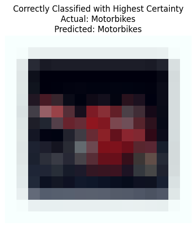

```
Acutal: Motorbikes
Predicted: Motorbikes
Probability of Motorbikes: 0.999965
Probability of airplanes: 0.000004
Probability of brain: 0.000019
Probability of butterfly: 0.000003
Probability of grand_piano: 0.000006
Probability of watch: 0.000003
```

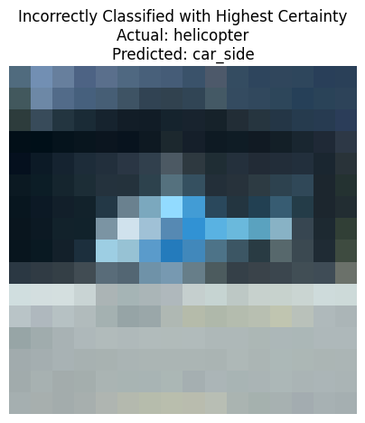

```
Acutal: helicopter
Predicted: car_side
Probability of Leopards: 0.000013
Probability of Motorbikes: 0.000002
Probability of airplanes: 0.000995
Probability of bonsai: 0.000034
Probability of buddha: 0.000224
Probability of car_side: 0.978049
Probability of chandelier: 0.000022
Probability of grand_piano: 0.000388
Probability of hawksbill: 0.003241
Probability of helicopter: 0.015567
Probability of kangaroo: 0.001237
Probability of ketch: 0.000007
Probability of menorah: 0.000004
Probability of starfish: 0.000055
Probability of watch: 0.000161
Evaluating best_model_regularizer_l1_l2
```

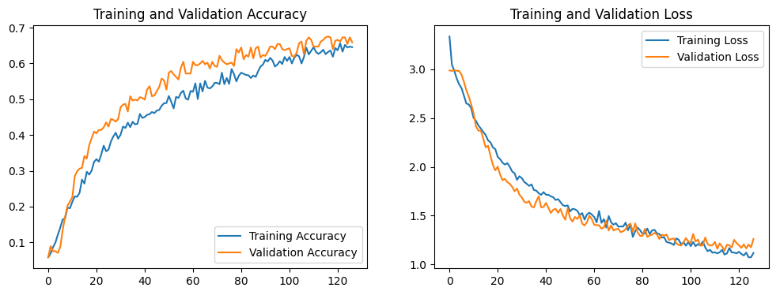

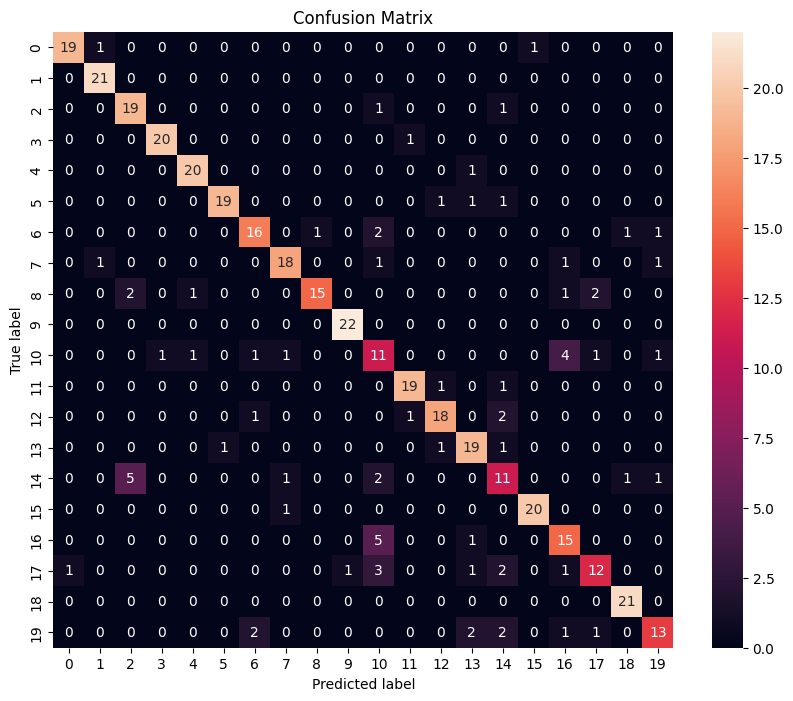

```
[[19  1  0  0  0  0  0  0  0  0  0  0  0  0  0  1  0  0  0  0]
 [ 0 21  0  0  0  0  0  0  0  0  0  0  0  0  0  0  0  0  0  0]
 [ 0  0 19  0  0  0  0  0  0  0  1  0  0  0  1  0  0  0  0  0]
 [ 0  0  0 20  0  0  0  0  0  0  0  1  0  0  0  0  0  0  0  0]
 [ 0  0  0  0 20  0  0  0  0  0  0  0  0  1  0  0  0  0  0  0]
 [ 0  0  0  0  0 19  0  0  0  0  0  0  1  1  1  0  0  0  0  0]
 [ 0  0  0  0  0  0 16  0  1  0  2  0  0  0  0  0  0  0  1  1]
 [ 0  1  0  0  0  0  0 18  0  0  1  0  0  0  0  0  1  0  0  1]
 [ 0  0  2  0  1  0  0  0 15  0  0  0  0  0  0  0  1  2  0  0]
 [ 0  0  0  0  0  0  0  0  0 22  0  0  0  0  0  0  0  0  0  0]
 [ 0  0  0  1  1  0  1  1  0  0 11  0  0  0  0  0  4  1  0  1]
 [ 0  0  0  0  0  0  0  0  0  0  0 19  1  0  1  0  0  0  0  0]
 [ 0  0  0  0  0  0  1  0  0  0  0  1 18  0  2  0  0  0  0  0]
 [ 0  0  0  0  0  1  0  0  0  0  0  0  1 19  1  0  0  0  0  0]
 [ 0  0  5  0  0  0  0  1  0  0  2  0  0  0 11  0  0  0  1  1]
 [ 0  0  0  0  0  0  0  1  0  0  0  0  0  0  0 20  0  0  0  0]
 [ 0  0  0  0  0  0  0  0  0  0  5  0  0  1  0  0 15  0  0  0]
 [ 1  0  0  0  0  0  0  0  0  1  3  0  0  1  2  0  1 12  0  0]
 [ 0  0  0  0  0  0  0  0  0  0  0  0  0  0  0  0  0  0 21  0]
 [ 0  0  0  0  0  0  2  0  0  0  0  0  0  2  2  0  1  1  0 13]]
              precision    recall  f1-score     support
Faces          0.950000  0.904762  0.926829   21.000000
Faces_easy     0.913043  1.000000  0.954545   21.000000
Leopards       0.730769  0.904762  0.808511   21.000000
Motorbikes     0.952381  0.952381  0.952381   21.000000
airplanes      0.909091  0.952381  0.930233   21.000000
bonsai         0.950000  0.863636  0.904762   22.000000
brain          0.800000  0.761905  0.780488   21.000000
buddha         0.857143  0.818182  0.837209   22.000000
butterfly      0.937500  0.714286  0.810811   21.000000
car_side       0.956522  1.000000  0.977778   22.000000
chandelier     0.440000  0.523810  0.478261   21.000000
grand_piano    0.904762  0.904762  0.904762   21.000000
hawksbill      0.857143  0.818182  0.837209   22.000000
helicopter     0.760000  0.863636  0.808511   22.000000
kangaroo       0.523810  0.523810  0.523810   21.000000
ketch          0.952381  0.952381  0.952381   21.000000
menorah        0.652174  0.714286  0.681818   21.000000
starfish       0.750000  0.571429  0.648649   21.000000
trilobite      0.913043  1.000000  0.954545   21.000000
watch          0.764706  0.619048  0.684211   21.000000
accuracy       0.818824  0.818824  0.818824    0.818824
macro avg      0.823723  0.818182  0.817885  425.000000
weighted avg   0.824340  0.818824  0.818535  425.000000
```

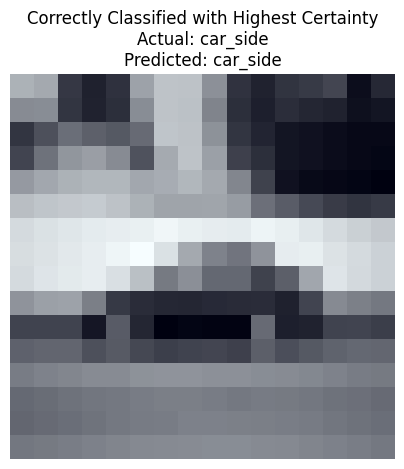

```
Acutal: car_side
Predicted: car_side
Probability of airplanes: 0.000036
Probability of car_side: 0.999913
Probability of grand_piano: 0.000003
Probability of helicopter: 0.000045
Probability of watch: 0.000001
```

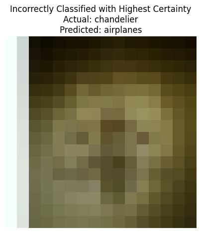

```
Acutal: chandelier
Predicted: airplanes
Probability of Faces: 0.000022
Probability of Leopards: 0.001396
Probability of Motorbikes: 0.005284
Probability of airplanes: 0.964329
Probability of bonsai: 0.004799
Probability of brain: 0.000518
Probability of buddha: 0.001151
Probability of butterfly: 0.003407
Probability of car_side: 0.000734
Probability of chandelier: 0.001592
Probability of grand_piano: 0.000373
Probability of hawksbill: 0.000382
Probability of helicopter: 0.011519
Probability of kangaroo: 0.000467
Probability of ketch: 0.000253
Probability of menorah: 0.000900
Probability of starfish: 0.002712
Probability of trilobite: 0.000006
Probability of watch: 0.000154
```

```python
best_model_names = ['best_model_regularizer_l1', 'best_model_regularizer_l1_l2']

for model_name in best_model_names:
    print(f"Evaluating {model_name}")
    model, history, X_test_std, y_test, lb = load_model_and_history(path_name, model_name)
    df_report = plot_and_evaluate_model(model, history, X_test_std, y_test, lb)
    print(df_report)
    show_predictions(model, X_test_std, y_test, lb, correctly_classified_images=1, incorrectly_classified_images=1)
```

## Comparative Analysis of Regularization Techniques in Convolutional Neural Networks

### Overview

This analysis compares the performance of two regularization techniques, `l1` and `l1_l2`, applied to a convolutional neural network. The focus is on understanding their impact on model performance, learning curves, overfitting, and training duration.

### 3. Training Duration and Model Complexity

- Both models have the same number of parameters (43,204), indicating similar model complexity.
- l1 Regularization: Slightly faster training time (69.88 seconds) compared to l1_l2.
- l1_l2 Regularization: Longer training time (74.86 seconds), but the increase is justifiable given the improved performance across classes.

### 5. Profitability of the Modification

- l1 Regularization: Ideal for applications where specific classes are more important and a slightly faster training is beneficial.
- l1_l2 Regularization: More suitable for applications requiring balanced performance across various classes, even if it means slightly longer training times.

### 6. Recommendations and Conclusions

- Best Model: The l1_l2 regularized model appears to be the best choice due to its balanced performance across different classes and better generalization capabilities.
- Suggested Modifications: For further improvements, experimenting with different regularization strengths or combining these techniques with other strategies like dropout could be beneficial.

```
Training model with relu activation
Loading existing model...
Model model_activation_relu_0 accuracy: 0.6823529411764706
Loading existing model...
Model model_activation_relu_1 accuracy: 0.7458823529411764
Loading existing model...
Model model_activation_relu_2 accuracy: 0.7623529411764706
Loading existing model...
Model model_activation_relu_3 accuracy: 0.7011764705882353
Loading existing model...
Model model_activation_relu_4 accuracy: 0.7270588235294118
Model best_model_activation_relu saved successfully.
Data for best_model_activation_relu saved successfully.
Saved best model model_activation_relu_2 with accuracy: 0.7623529411764706

Training model with tanh activation
Loading existing model...
Model model_activation_tanh_0 accuracy: 0.7011764705882353
Loading existing model...
Model model_activation_tanh_1 accuracy: 0.6870588235294117
Loading existing model...
Model model_activation_tanh_2 accuracy: 0.7082352941176471
Loading existing model...
Model model_activation_tanh_3 accuracy: 0.6729411764705883
Loading existing model...
Model model_activation_tanh_4 accuracy: 0.6352941176470588
Model best_model_activation_tanh saved successfully.
Data for best_model_activation_tanh saved successfully.
Saved best model model_activation_tanh_2 with accuracy: 0.7082352941176471

Training model with sigmoid activation
Loading existing model...
Model model_activation_sigmoid_0 accuracy: 0.68
Loading existing model...
Model model_activation_sigmoid_1 accuracy: 0.8
Loading existing model...
Model model_activation_sigmoid_2 accuracy: 0.64
Loading existing model...
Model model_activation_sigmoid_3 accuracy: 0.7035294117647058
Loading existing model...
Model model_activation_sigmoid_4 accuracy: 0.7105882352941176
Model best_model_activation_sigmoid saved successfully.
Data for best_model_activation_sigmoid saved successfully.
Saved best model model_activation_sigmoid_1 with accuracy: 0.8
```

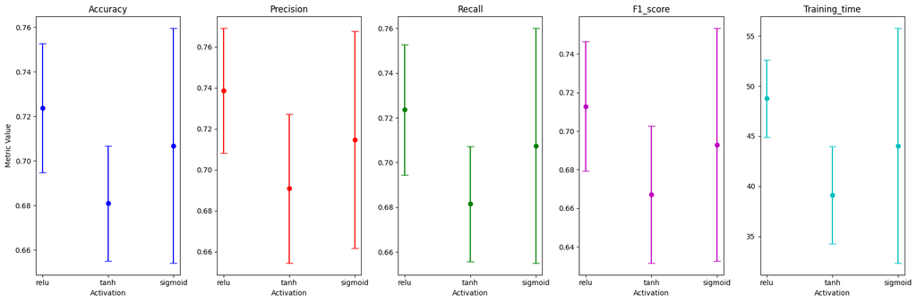

```
Evaluation metrics with standard deviation: {'activation': ['relu', 'tanh', 'sigmoid'], 'accuracy': {'mean': [0.7237647058823529, 0.6809411764705883, 0.7068235294117647], 'std': [0.029031899887411148, 0.025843821586345385, 0.052710083866149095]}, 'precision': {'mean': [0.7387001614128457, 0.69091742…
```

```python
activation_functions = ['relu', 'tanh', 'sigmoid']

path_name = "models_activation"

evaluation_metrics = {
    'activation': [],
    'accuracy': {'mean': [], 'std': []},
    'precision': {'mean': [], 'std': []},
    'recall': {'mean': [], 'std': []},
    'f1_score': {'mean': [], 'std': []},
    'training_time': {'mean': [], 'std': []}
}

images, labels, one_hot_labels, lb = load_images_from_folder(data_folder, target_size=(16, 16))

for activation in activation_functions:
    print(f"\nTraining model with {activation} activation")
    accuracies, precisions, recalls, f1_scores, training_times = [], [], [], [], []

    best_model = None
    best_model_name = None
    best_accuracy = 0
    best_history = None
    best_training_time = None

    for i in range(5):
        X_train_std, X_test_std, y_train, y_test, lb = prepare_train_test_sets(images, labels, test_size=0.25, random_state=42)
        model_name = f"model_activation_{activation}_{i}"
        model, history, training_time, num_params, X_test, y_test, lb = create_and_train_model(model, X_train_std, y_train, X_test_std, y_test, lb, X_train_std.shape[1:], y_train.shape[1], path_name, model_name, dropout_rate=0.4, activation=activation, use_regularizer='l1_l2')

        y_pred = model.predict(X_test)
        y_pred_classes = np.argmax(y_pred, axis=1)
        y_true = np.argmax(y_test, axis=1)
        report = classification_report(y_true, y_pred_classes, output_dict=True, zero_division=1)

        accuracies.append(report['accuracy'])
        precisions.append(report['macro avg']['precision'])
        recalls.append(report['macro avg']['recall'])
        f1_scores.append(report['macro avg']['f1-score'])
        training_times.append(training_time)

        current_accuracy = report['accuracy']
        if current_accuracy > best_accuracy:
            best_accuracy = current_accuracy
            best_model = model
            best_model_name = model_name
            best_history = history
            best_training_time = training_time

        print(f"Model {model_name} accuracy: {current_accuracy}")

    evaluation_metrics['activation'].append(activation)
    evaluation_metrics['accuracy']['mean'].append(np.mean(accuracies))
    evaluation_metrics['accuracy']['std'].append(np.std(accuracies))
    evaluation_metrics['precision']['mean'].append(np.mean(precisions))
    evaluation_metrics['precision']['std'].append(np.std(precisions))
    evaluation_metrics['recall']['mean'].append(np.mean(recalls))
    evaluation_metrics['recall']['std'].append(np.std(recalls))
    evaluation_metrics['f1_score']['mean'].append(np.mean(f1_scores))
    evaluation_metrics['f1_score']['std'].append(np.std(f1_scores))
    evaluation_metrics['training_time']['mean'].append(np.mean(training_times))
    evaluation_metrics['training_time']['std'].append(np.std(training_times))

    if best_model:
        save_model_and_data(best_model, best_history, best_training_time, num_params, path_name, f"best_model_activation_{activation}", X_test, y_test, lb)
        print(f"Saved best model {best_model_name} with accuracy: {best_accuracy}")

plt.figure(figsize=(18, 6))

def plot_with_error(metric_name, subplot_index, color):
    plt.subplot(1, 5, subplot_index)
    plt.errorbar(evaluation_metrics['activation'],
                    evaluation_metrics[metric_name]['mean'],
                    yerr=evaluation_metrics[metric_name]['std'],
                    fmt='o', ecolor=color, capsize=5, color=color)
    plt.title(metric_name.capitalize())
    plt.xlabel('Activation')
    if subplot_index == 1:
        plt.ylabel('Metric Value')

plot_with_error('accuracy', 1, 'b')
plot_with_error('precision', 2, 'r')
plot_with_error('recall', 3, 'g')
plot_with_error('f1_score', 4, 'm')
plot_with_error('training_time', 5, 'c')

plt.tight_layout()
plt.show()

print("Evaluation metrics with standard deviation:", evaluation_metrics)
```

## Comparative Analysis of Activation Functions in Convolutional Neural Networks

### Overview

This analysis compares three activation functions: ReLU, Tanh, and Sigmoid, in the context of their impact on a convolutional neural network's performance.

### 2. Comparison of Learning Duration and Model Complexity

- **ReLU Activation**: Average training time was the longest (48.77 seconds), but the consistent performance could justify this.
- **Tanh Activation**: Faster training (39.12 seconds on average), which is beneficial for time-sensitive applications.
- **Sigmoid Activation**: Intermediate training duration (44.05 seconds), with significant variation in training times.

### 4. Considerations and Recommendations

- **ReLU Activation**: Best suited for scenarios where reliability and consistent performance are prioritized over training speed.
- **Tanh Activation**: Could be considered for simpler or less complex tasks where training speed is a significant factor.
- **Sigmoid Activation**: Potentially useful in cases where achieving the highest possible accuracy on certain tasks outweighs the need for consistent performance across multiple runs.

### Conclusion

The choice of activation function should be influenced by the specific requirements of the task at hand, considering factors such as the need for speed, consistency, and maximum achievable accuracy. Further experimentation, possibly combining different activation functions or incorporating other network modifications, might lead to improved performance based on the specific dataset and task requirements.

```
Evaluating best_model_activation_relu
```

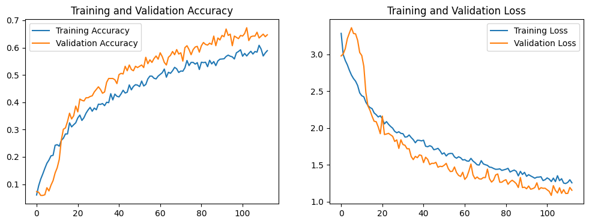

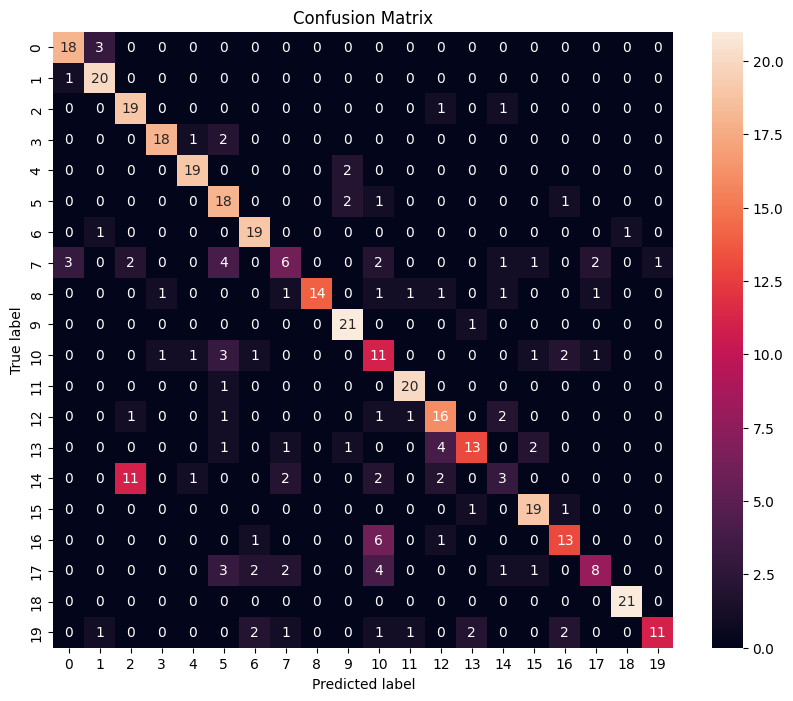

```
[[18  3  0  0  0  0  0  0  0  0  0  0  0  0  0  0  0  0  0  0]
 [ 1 20  0  0  0  0  0  0  0  0  0  0  0  0  0  0  0  0  0  0]
 [ 0  0 19  0  0  0  0  0  0  0  0  0  1  0  1  0  0  0  0  0]
 [ 0  0  0 18  1  2  0  0  0  0  0  0  0  0  0  0  0  0  0  0]
 [ 0  0  0  0 19  0  0  0  0  2  0  0  0  0  0  0  0  0  0  0]
 [ 0  0  0  0  0 18  0  0  0  2  1  0  0  0  0  0  1  0  0  0]
 [ 0  1  0  0  0  0 19  0  0  0  0  0  0  0  0  0  0  0  1  0]
 [ 3  0  2  0  0  4  0  6  0  0  2  0  0  0  1  1  0  2  0  1]
 [ 0  0  0  1  0  0  0  1 14  0  1  1  1  0  1  0  0  1  0  0]
 [ 0  0  0  0  0  0  0  0  0 21  0  0  0  1  0  0  0  0  0  0]
 [ 0  0  0  1  1  3  1  0  0  0 11  0  0  0  0  1  2  1  0  0]
 [ 0  0  0  0  0  1  0  0  0  0  0 20  0  0  0  0  0  0  0  0]
 [ 0  0  1  0  0  1  0  0  0  0  1  1 16  0  2  0  0  0  0  0]
 [ 0  0  0  0  0  1  0  1  0  1  0  0  4 13  0  2  0  0  0  0]
 [ 0  0 11  0  1  0  0  2  0  0  2  0  2  0  3  0  0  0  0  0]
 [ 0  0  0  0  0  0  0  0  0  0  0  0  0  1  0 19  1  0  0  0]
 [ 0  0  0  0  0  0  1  0  0  0  6  0  1  0  0  0 13  0  0  0]
 [ 0  0  0  0  0  3  2  2  0  0  4  0  0  0  1  1  0  8  0  0]
 [ 0  0  0  0  0  0  0  0  0  0  0  0  0  0  0  0  0  0 21  0]
 [ 0  1  0  0  0  0  2  1  0  0  1  1  0  2  0  0  2  0  0 11]]
              precision    recall  f1-score     support
Faces          0.818182  0.857143  0.837209   21.000000
Faces_easy     0.800000  0.952381  0.869565   21.000000
Leopards       0.575758  0.904762  0.703704   21.000000
Motorbikes     0.900000  0.857143  0.878049   21.000000
airplanes      0.863636  0.904762  0.883721   21.000000
bonsai         0.545455  0.818182  0.654545   22.000000
brain          0.760000  0.904762  0.826087   21.000000
buddha         0.461538  0.272727  0.342857   22.000000
butterfly      1.000000  0.666667  0.800000   21.000000
car_side       0.807692  0.954545  0.875000   22.000000
chandelier     0.379310  0.523810  0.440000   21.000000
grand_piano    0.869565  0.952381  0.909091   21.000000
hawksbill      0.640000  0.727273  0.680851   22.000000
helicopter     0.764706  0.590909  0.666667   22.000000
kangaroo       0.333333  0.142857  0.200000   21.000000
ketch          0.791667  0.904762  0.844444   21.000000
menorah        0.684211  0.619048  0.650000   21.000000
starfish       0.666667  0.380952  0.484848   21.000000
trilobite      0.954545  1.000000  0.976744   21.000000
watch          0.916667  0.523810  0.666667   21.000000
accuracy       0.722353  0.722353  0.722353    0.722353
macro avg      0.726647  0.722944  0.709502  425.000000
weighted avg   0.725673  0.722353  0.708732  425.000000
```

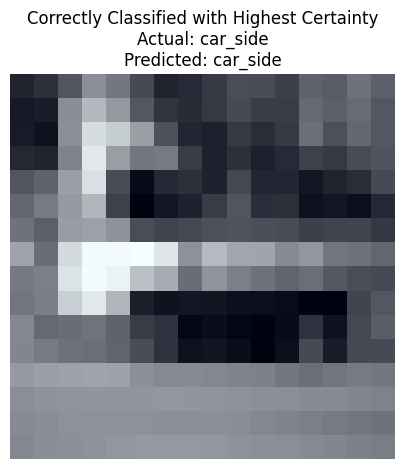

```
Acutal: car_side
Predicted: car_side
Probability of Leopards: 0.000001
Probability of airplanes: 0.000017
Probability of bonsai: 0.000014
Probability of buddha: 0.000066
Probability of car_side: 0.999466
Probability of grand_piano: 0.000004
Probability of hawksbill: 0.000028
Probability of helicopter: 0.000343
Probability of kangaroo: 0.000042
Probability of ketch: 0.000007
Probability of watch: 0.000011
```

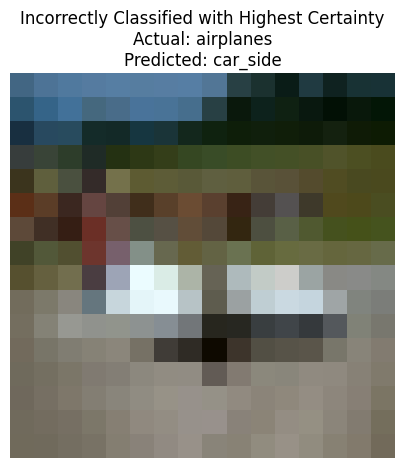

```
Acutal: airplanes
Predicted: car_side
Probability of Leopards: 0.000019
Probability of airplanes: 0.002003
Probability of bonsai: 0.000268
Probability of buddha: 0.000661
Probability of car_side: 0.990400
Probability of chandelier: 0.000016
Probability of grand_piano: 0.000021
Probability of hawksbill: 0.000261
Probability of helicopter: 0.005922
Probability of kangaroo: 0.000225
Probability of ketch: 0.000133
Probability of menorah: 0.000004
Probability of starfish: 0.000017
Probability of watch: 0.000048
Evaluating best_model_activation_sigmoid
```

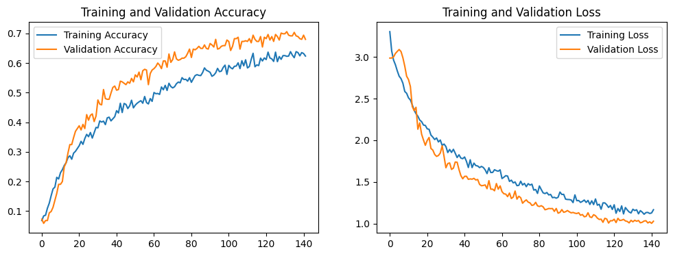

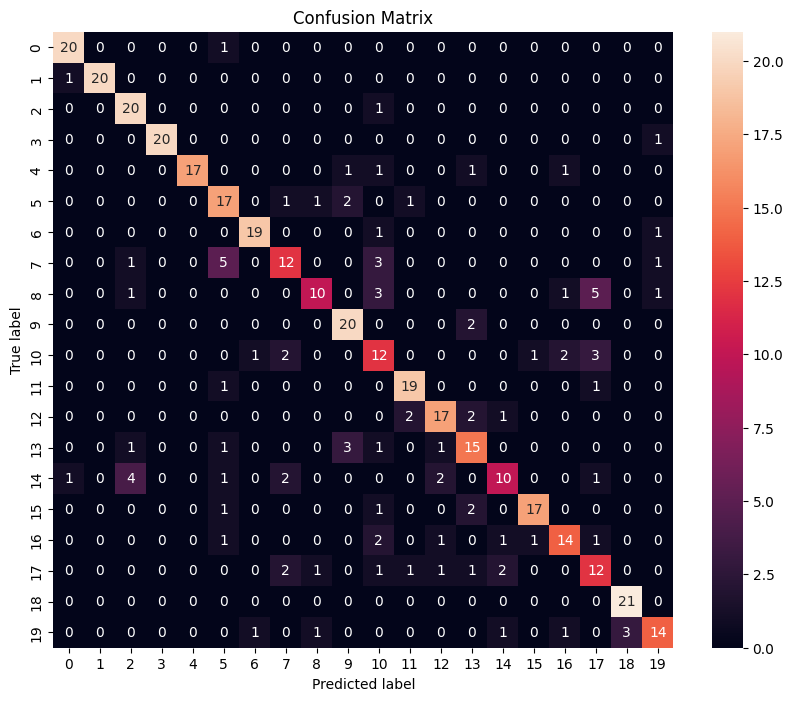

```
[[20  0  0  0  0  1  0  0  0  0  0  0  0  0  0  0  0  0  0  0]
 [ 1 20  0  0  0  0  0  0  0  0  0  0  0  0  0  0  0  0  0  0]
 [ 0  0 20  0  0  0  0  0  0  0  1  0  0  0  0  0  0  0  0  0]
 [ 0  0  0 20  0  0  0  0  0  0  0  0  0  0  0  0  0  0  0  1]
 [ 0  0  0  0 17  0  0  0  0  1  1  0  0  1  0  0  1  0  0  0]
 [ 0  0  0  0  0 17  0  1  1  2  0  1  0  0  0  0  0  0  0  0]
 [ 0  0  0  0  0  0 19  0  0  0  1  0  0  0  0  0  0  0  0  1]
 [ 0  0  1  0  0  5  0 12  0  0  3  0  0  0  0  0  0  0  0  1]
 [ 0  0  1  0  0  0  0  0 10  0  3  0  0  0  0  0  1  5  0  1]
 [ 0  0  0  0  0  0  0  0  0 20  0  0  0  2  0  0  0  0  0  0]
 [ 0  0  0  0  0  0  1  2  0  0 12  0  0  0  0  1  2  3  0  0]
 [ 0  0  0  0  0  1  0  0  0  0  0 19  0  0  0  0  0  1  0  0]
 [ 0  0  0  0  0  0  0  0  0  0  0  2 17  2  1  0  0  0  0  0]
 [ 0  0  1  0  0  1  0  0  0  3  1  0  1 15  0  0  0  0  0  0]
 [ 1  0  4  0  0  1  0  2  0  0  0  0  2  0 10  0  0  1  0  0]
 [ 0  0  0  0  0  1  0  0  0  0  1  0  0  2  0 17  0  0  0  0]
 [ 0  0  0  0  0  1  0  0  0  0  2  0  1  0  1  1 14  1  0  0]
 [ 0  0  0  0  0  0  0  2  1  0  1  1  1  1  2  0  0 12  0  0]
 [ 0  0  0  0  0  0  0  0  0  0  0  0  0  0  0  0  0  0 21  0]
 [ 0  0  0  0  0  0  1  0  1  0  0  0  0  0  1  0  1  0  3 14]]
              precision    recall  f1-score     support
Faces          0.909091  0.952381  0.930233   21.000000
Faces_easy     1.000000  0.952381  0.975610   21.000000
Leopards       0.740741  0.952381  0.833333   21.000000
Motorbikes     1.000000  0.952381  0.975610   21.000000
airplanes      1.000000  0.809524  0.894737   21.000000
bonsai         0.607143  0.772727  0.680000   22.000000
brain          0.904762  0.904762  0.904762   21.000000
buddha         0.631579  0.545455  0.585366   22.000000
butterfly      0.769231  0.476190  0.588235   21.000000
car_side       0.769231  0.909091  0.833333   22.000000
chandelier     0.461538  0.571429  0.510638   21.000000
grand_piano    0.826087  0.904762  0.863636   21.000000
hawksbill      0.772727  0.772727  0.772727   22.000000
helicopter     0.652174  0.681818  0.666667   22.000000
kangaroo       0.666667  0.476190  0.555556   21.000000
ketch          0.894737  0.809524  0.850000   21.000000
menorah        0.736842  0.666667  0.700000   21.000000
starfish       0.521739  0.571429  0.545455   21.000000
trilobite      0.875000  1.000000  0.933333   21.000000
watch          0.777778  0.666667  0.717949   21.000000
accuracy       0.767059  0.767059  0.767059    0.767059
macro avg      0.775853  0.767424  0.765859  425.000000
weighted avg   0.774803  0.767059  0.765174  425.000000
```

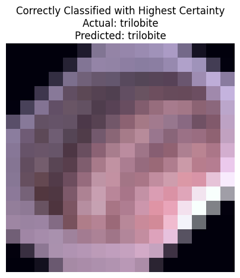

```
Acutal: trilobite
Predicted: trilobite
Probability of brain: 0.000069
Probability of butterfly: 0.000009
Probability of hawksbill: 0.000003
Probability of trilobite: 0.999918
```

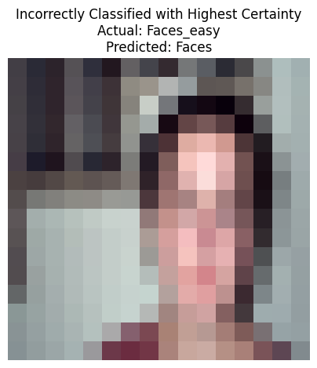

```
Acutal: Faces_easy
Predicted: Faces
Probability of Faces: 0.993216
Probability of Faces_easy: 0.001996
Probability of Leopards: 0.000003
Probability of bonsai: 0.000001
Probability of brain: 0.000016
Probability of buddha: 0.000531
Probability of butterfly: 0.000338
Probability of chandelier: 0.000079
Probability of grand_piano: 0.000008
Probability of hawksbill: 0.000056
Probability of helicopter: 0.000004
Probability of kangaroo: 0.002455
Probability of ketch: 0.000083
Probability of menorah: 0.000027
Probability of starfish: 0.001066
Probability of trilobite: 0.000003
Probability of watch: 0.000118
```

```python
best_model_names = ['best_model_activation_relu', 'best_model_activation_sigmoid']

for model_name in best_model_names:
    print(f"Evaluating {model_name}")
    model, history, X_test_std, y_test, lb = load_model_and_history(path_name, model_name)
    df_report = plot_and_evaluate_model(model, history, X_test_std, y_test, lb)
    print(df_report)
    show_predictions(model, X_test_std, y_test, lb, correctly_classified_images=1, incorrectly_classified_images=1)
```

# Analysis and Comparison of Convolutional Neural Network Models

## 1. Overall Predictive Ability of the Models

- **Model A (ReLU Activation):**
  - Average accuracy: 72.24%.
  - High precision and recall in classes like 'Faces' and 'Motorbikes'.
  - Effective for classes with distinctive features.
- **Model B (Sigmoid Activation):**
  - Average accuracy: 76.71%.
  - Excellent precision and recall in classes like 'Trilobite' and 'Faces_easy'.
  - More versatile across varied classes.

## 3. Learning Duration and Model Complexity

- **Model A (ReLU Activation):**
  - Training time: 51.96 seconds.
  - Number of parameters: 43,204.
- **Model B (Sigmoid Activation):**
  - Training time: 66.13 seconds.
  - Number of parameters: 43,204.

## 4. Profitability of Modification

- The modification to Sigmoid activation (Model B) seems beneficial, considering the higher accuracy and better generalization across classes.
- The increased training time is justified by the gains in model performance.

## 5. Learning Curve Shape and Optimization

- **Model A (ReLU Activation):**
  - Steady decrease in loss and increase in accuracy, but plateaus suggest limitations in learning complex patterns.
- **Model B (Sigmoid Activation):**
  - More dynamic learning curve, adapting better to varying data patterns.
  - Consistent improvement in test accuracy and loss, indicative of effective learning.

## 6. Recommendations and Further Modifications

- For Model A, exploring different architectures or hyperparameters could address underfitting issues.
- Model B could be further optimized by tweaking learning rates or adding regularization to enhance its performance on complex classes.

```
Training model with batch normalization: True
Training new model...
Model model_batch_norm_True_0 saved successfully.
Data for model_batch_norm_True_0 saved successfully.
Model model_batch_norm_True_0 accuracy: 0.6211764705882353
Training new model...
Model model_batch_norm_True_1 saved successfully.
Data for model_batch_norm_True_1 saved successfully.
Model model_batch_norm_True_1 accuracy: 0.6635294117647059
Training new model...
Model model_batch_norm_True_2 saved successfully.
Data for model_batch_norm_True_2 saved successfully.
Model model_batch_norm_True_2 accuracy: 0.5458823529411765
Training new model...
Model model_batch_norm_True_3 saved successfully.
Data for model_batch_norm_True_3 saved successfully.
Model model_batch_norm_True_3 accuracy: 0.5952941176470589
Training new model...
Model model_batch_norm_True_4 saved successfully.
Data for model_batch_norm_True_4 saved successfully.
Model model_batch_norm_True_4 accuracy: 0.6894117647058824
Model best_model_batch_norm_True saved successfully.
Data for best_model_batch_norm_True saved successfully.
Saved best model model_batch_norm_True_4 with accuracy: 0.6894117647058824

Training model with batch normalization: False
Training new model...
Model model_batch_norm_False_0 saved successfully.
Data for model_batch_norm_False_0 saved successfully.
Model model_batch_norm_False_0 accuracy: 0.5976470588235294
Training new model...
Model model_batch_norm_False_1 saved successfully.
Data for model_batch_norm_False_1 saved successfully.
Model model_batch_norm_False_1 accuracy: 0.6258823529411764
Training new model...
Model model_batch_norm_False_2 saved successfully.
Data for model_batch_norm_False_2 saved successfully.
Model model_batch_norm_False_2 accuracy: 0.6141176470588235
Training new model...
Model model_batch_norm_False_3 saved successfully.
Data for model_batch_norm_False_3 saved successfully.
Model model_batch_norm_False_3 accuracy: 0.5694117647058824
Training new model...
Model model_batch_norm_False_4 saved successfully.
Data for model_batch_norm_False_4 saved successfully.
Model model_batch_norm_False_4 accuracy: 0.6658823529411765
Model best_model_batch_norm_False saved successfully.
Data for best_model_batch_norm_False saved successfully.
Saved best model model_batch_norm_False_4 with accuracy: 0.6658823529411765
```

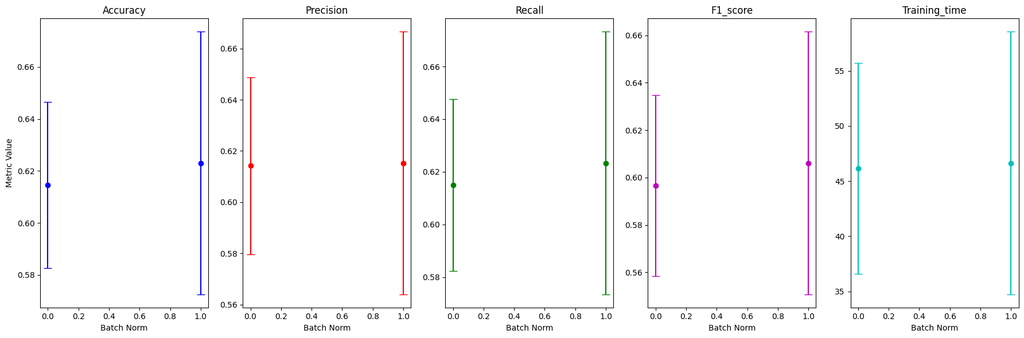

```
Evaluation metrics with standard deviation: {'batch_norm': [True, False], 'accuracy': {'mean': [0.6230588235294118, 0.6145882352941177], 'std': [0.050539511419609835, 0.03189602485238689]}, 'precision': {'mean': [0.6152916756609912, 0.6141851827013591], 'std': [0.051327594851917915, 0.03451471904086…
```

```python
batch_norms = [True, False]

path_name = "models_batch_norm"

evaluation_metrics = {
    'batch_norm': [],
    'accuracy': {'mean': [], 'std': []},
    'precision': {'mean': [], 'std': []},
    'recall': {'mean': [], 'std': []},
    'f1_score': {'mean': [], 'std': []},
    'training_time': {'mean': [], 'std': []}
}

images, labels, one_hot_labels, lb = load_images_from_folder(data_folder, target_size=(16, 16))

for batch_norm in batch_norms:
    print(f"\nTraining model with batch normalization: {batch_norm}")
    accuracies, precisions, recalls, f1_scores, training_times = [], [], [], [], []

    best_model = None
    best_model_name = None
    best_accuracy = 0
    best_history = None
    best_training_time = None

    for i in range(5):
        X_train_std, X_test_std, y_train, y_test, lb = prepare_train_test_sets(images, labels, test_size=0.25)
        model_name = f"model_batch_norm_{batch_norm}_{i}"
        model, history, training_time, num_params, X_test, y_test, lb = create_and_train_model(model, X_train_std, y_train, X_test_std, y_test, lb, X_train_std.shape[1:], y_train.shape[1], path_name, model_name, dropout_rate=0.4, activation='relu', use_regularizer='l1_l2', use_batch_norm=batch_norm)

        y_pred = model.predict(X_test)
        y_pred_classes = np.argmax(y_pred, axis=1)
        y_true = np.argmax(y_test, axis=1)
        report = classification_report(y_true, y_pred_classes, output_dict=True, zero_division=1)

        accuracies.append(report['accuracy'])
        precisions.append(report['macro avg']['precision'])
        recalls.append(report['macro avg']['recall'])
        f1_scores.append(report['macro avg']['f1-score'])
        training_times.append(training_time)

        current_accuracy = report['accuracy']
        if current_accuracy > best_accuracy:
            best_accuracy = current_accuracy
            best_model = model
            best_model_name = model_name
            best_history = history
            best_training_time = training_time

        print(f"Model {model_name} accuracy: {current_accuracy}")

    evaluation_metrics['batch_norm'].append(batch_norm)
    evaluation_metrics['accuracy']['mean'].append(np.mean(accuracies))
    evaluation_metrics['accuracy']['std'].append(np.std(accuracies))
    evaluation_metrics['precision']['mean'].append(np.mean(precisions))
    evaluation_metrics['precision']['std'].append(np.std(precisions))
    evaluation_metrics['recall']['mean'].append(np.mean(recalls))
    evaluation_metrics['recall']['std'].append(np.std(recalls))
    evaluation_metrics['f1_score']['mean'].append(np.mean(f1_scores))
    evaluation_metrics['f1_score']['std'].append(np.std(f1_scores))
    evaluation_metrics['training_time']['mean'].append(np.mean(training_times))
    evaluation_metrics['training_time']['std'].append(np.std(training_times))

    if best_model:
        save_model_and_data(best_model, best_history, best_training_time, num_params, path_name, f"best_model_batch_norm_{batch_norm}", X_test, y_test, lb)
        print(f"Saved best model {best_model_name} with accuracy: {best_accuracy}")

plt.figure(figsize=(18, 6))

def plot_with_error(metric_name, subplot_index, color):
    plt.subplot(1, 5, subplot_index)
    plt.errorbar(evaluation_metrics['batch_norm'],
                    evaluation_metrics[metric_name]['mean'],
                    yerr=evaluation_metrics[metric_name]['std'],
                    fmt='o', ecolor=color, capsize=5, color=color)
    plt.title(metric_name.capitalize())
    plt.xlabel('Batch Norm')
    if subplot_index == 1:
        plt.ylabel('Metric Value')

plot_with_error('accuracy', 1, 'b')
plot_with_error('precision', 2, 'r')
plot_with_error('recall', 3, 'g')
plot_with_error('f1_score', 4, 'm')
plot_with_error('training_time', 5, 'c')

plt.tight_layout()
plt.show()

print("Evaluation metrics with standard deviation:", evaluation_metrics)
```

# Comparative Analysis of Neural Network Models with and without Batch Normalization

## 1. Overall Predictive Ability of the Models

- **Model with Batch Normalization:**
  - Best accuracy: 68.94%.
  - Average accuracy: 62.31%.
  - Standard deviation in accuracy: 5.05%.
- **Model without Batch Normalization:**
  - Best accuracy: 66.59%.
  - Average accuracy: 61.46%.
  - Standard deviation in accuracy: 3.19%.

### Conclusion:

- The model with batch normalization slightly outperforms the model without batch normalization in terms of best and average accuracy. However, the increased standard deviation suggests variability in its performance.

## 2. Comparison of Learning Duration and Model Complexity

- Both models have similar training times (around 46 seconds on average), indicating that the inclusion of batch normalization does not significantly impact the training duration.
- The standard deviation in training times is slightly higher for the model with batch normalization, which may suggest variable convergence times across different runs.

## 3. Profitability of Batch Normalization

- The improvement in accuracy with batch normalization is modest. Therefore, whether this improvement justifies the added complexity of batch normalization depends on the specific requirements of the application.
- In applications where every fraction of a percent in accuracy is critical, batch normalization may be justified.

## 4. Potential Issues and Suggestions

- The higher standard deviation in accuracy for the batch normalization model may indicate issues like overfitting or instability in certain training scenarios.
- To address this, it might be worthwhile to explore different model architectures or to fine-tune the batch normalization parameters.
- Additionally, further experiments with different training data distributions or augmentation techniques could provide more insight into the model's behavior.

Overall, the decision to use batch normalization should be based on specific use-case requirements, considering the balance between accuracy improvement and model complexity.

```
Evaluating best_model_batch_norm_True
```

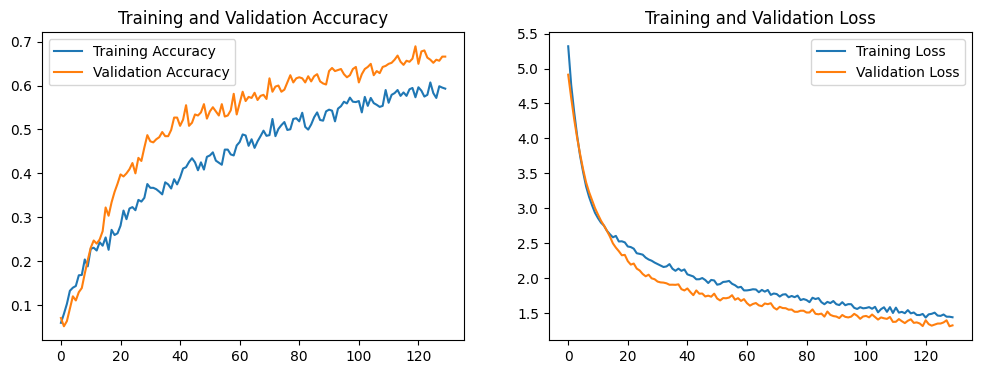

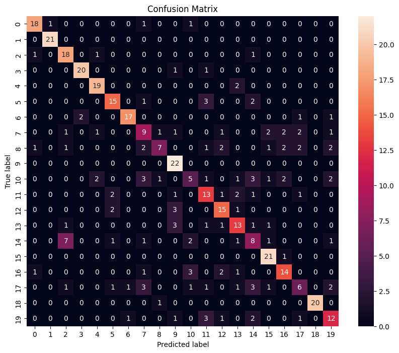

```
[[18  1  0  0  0  0  0  1  0  0  1  0  0  0  0  0  0  0  0  0]
 [ 0 21  0  0  0  0  0  0  0  0  0  0  0  0  0  0  0  0  0  0]
 [ 1  0 18  0  1  0  0  0  0  0  0  0  0  0  1  0  0  0  0  0]
 [ 0  0  0 20  0  0  0  0  0  1  0  1  0  0  0  0  0  0  0  0]
 [ 0  0  0  0 19  0  0  0  0  0  0  0  0  2  0  0  0  0  0  0]
 [ 0  0  0  0  0 15  0  1  0  0  0  3  0  0  2  0  0  0  0  0]
 [ 0  0  0  2  0  0 17  0  0  0  0  0  0  0  0  0  0  1  0  1]
 [ 0  0  1  0  1  0  0  9  1  1  0  0  1  0  0  2  2  2  0  1]
 [ 1  0  1  0  0  0  0  2  7  0  0  1  2  0  0  1  2  2  0  2]
 [ 0  0  0  0  0  0  0  0  0 22  0  0  0  0  0  0  0  0  0  0]
 [ 0  0  0  0  2  0  0  3  1  0  5  1  0  1  3  1  2  0  0  2]
 [ 0  0  0  0  0  2  0  0  0  1  0 13  1  2  1  0  0  1  0  0]
 [ 0  0  0  0  0  2  0  0  0  3  0  0 15  1  0  0  0  0  0  0]
 [ 0  0  1  0  0  0  0  0  0  3  0  1  1 13  1  1  0  0  0  0]
 [ 0  0  7  0  0  1  0  1  0  0  2  0  0  1  8  1  0  0  0  1]
 [ 0  0  0  0  0  0  0  0  0  0  0  0  0  0  0 21  1  0  0  0]
 [ 1  0  0  0  0  0  0  1  0  0  3  0  2  1  0  0 14  0  0  0]
 [ 0  0  1  0  0  1  1  3  0  0  1  1  0  1  3  1  0  6  0  2]
 [ 0  0  0  0  0  0  0  0  1  0  0  0  0  0  0  0  0  0 20  0]
 [ 0  0  0  0  0  0  1  0  0  1  0  3  1  0  2  0  0  1  0 12]]
              precision    recall  f1-score     support
Faces          0.857143  0.857143  0.857143   21.000000
Faces_easy     0.954545  1.000000  0.976744   21.000000
Leopards       0.620690  0.857143  0.720000   21.000000
Motorbikes     0.909091  0.909091  0.909091   22.000000
airplanes      0.826087  0.904762  0.863636   21.000000
bonsai         0.714286  0.714286  0.714286   21.000000
brain          0.894737  0.809524  0.850000   21.000000
buddha         0.428571  0.428571  0.428571   21.000000
butterfly      0.700000  0.333333  0.451613   21.000000
car_side       0.687500  1.000000  0.814815   22.000000
chandelier     0.416667  0.238095  0.303030   21.000000
grand_piano    0.541667  0.619048  0.577778   21.000000
hawksbill      0.652174  0.714286  0.681818   21.000000
helicopter     0.590909  0.619048  0.604651   21.000000
kangaroo       0.380952  0.363636  0.372093   22.000000
ketch          0.750000  0.954545  0.840000   22.000000
menorah        0.666667  0.636364  0.651163   22.000000
starfish       0.461538  0.285714  0.352941   21.000000
trilobite      1.000000  0.952381  0.975610   21.000000
watch          0.571429  0.571429  0.571429   21.000000
accuracy       0.689412  0.689412  0.689412    0.689412
macro avg      0.681233  0.688420  0.675821  425.000000
weighted avg   0.681204  0.689412  0.676310  425.000000
```

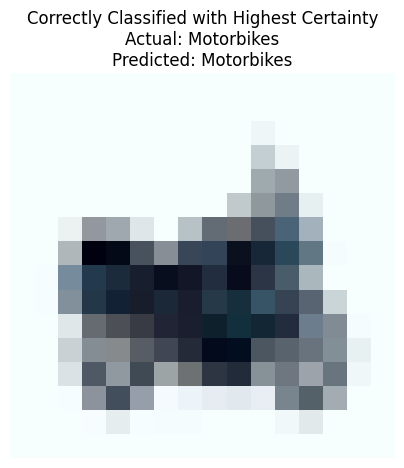

```
Acutal: Motorbikes
Predicted: Motorbikes
Probability of Motorbikes: 0.999178
Probability of airplanes: 0.000432
Probability of brain: 0.000023
Probability of butterfly: 0.000079
Probability of chandelier: 0.000006
Probability of grand_piano: 0.000266
Probability of hawksbill: 0.000005
Probability of helicopter: 0.000003
Probability of starfish: 0.000001
Probability of watch: 0.000006
```

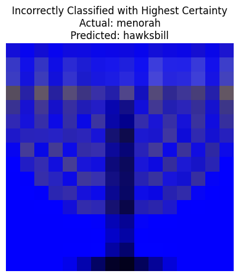

```
Acutal: menorah
Predicted: hawksbill
Probability of Leopards: 0.003110
Probability of Motorbikes: 0.000016
Probability of airplanes: 0.002792
Probability of bonsai: 0.007825
Probability of brain: 0.000104
Probability of buddha: 0.000632
Probability of butterfly: 0.001226
Probability of car_side: 0.000037
Probability of chandelier: 0.000299
Probability of grand_piano: 0.004012
Probability of hawksbill: 0.948520
Probability of helicopter: 0.022159
Probability of kangaroo: 0.004569
Probability of ketch: 0.000068
Probability of menorah: 0.002752
Probability of starfish: 0.000907
Probability of trilobite: 0.000732
Probability of watch: 0.000239
Evaluating best_model_batch_norm_False
```

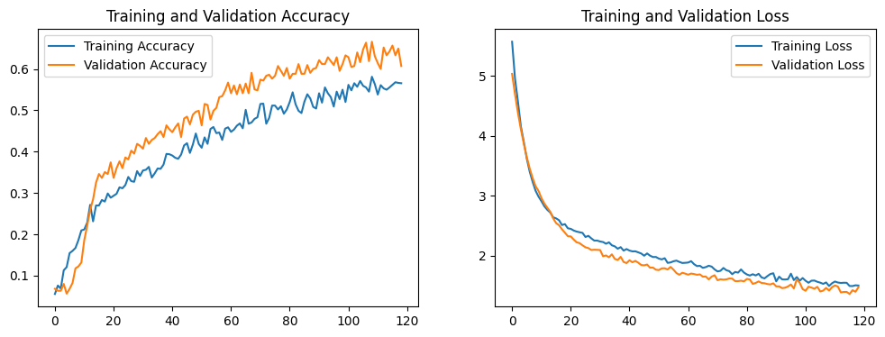

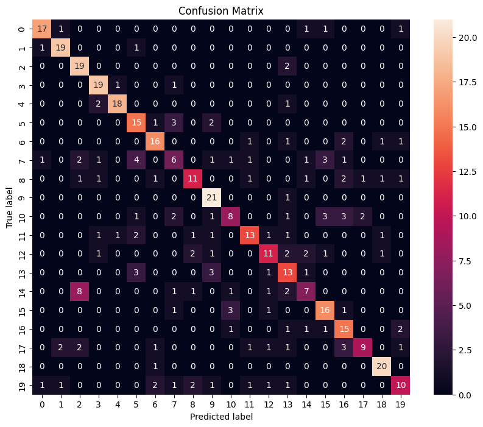

```
[[17  1  0  0  0  0  0  0  0  0  0  0  0  0  1  1  0  0  0  1]
 [ 1 19  0  0  0  1  0  0  0  0  0  0  0  0  0  0  0  0  0  0]
 [ 0  0 19  0  0  0  0  0  0  0  0  0  0  2  0  0  0  0  0  0]
 [ 0  0  0 19  1  0  0  1  0  0  0  0  0  0  0  0  0  0  0  0]
 [ 0  0  0  2 18  0  0  0  0  0  0  0  0  1  0  0  0  0  0  0]
 [ 0  0  0  0  0 15  1  3  0  2  0  0  0  0  0  0  0  0  0  0]
 [ 0  0  0  0  0  0 16  0  0  0  0  1  0  1  0  0  2  0  1  1]
 [ 1  0  2  1  0  4  0  6  0  1  1  1  0  0  1  3  1  0  0  0]
 [ 0  0  1  1  0  0  1  0 11  0  0  1  0  0  1  0  2  1  1  1]
 [ 0  0  0  0  0  0  0  0  0 21  0  0  0  1  0  0  0  0  0  0]
 [ 0  0  0  0  0  1  0  2  0  1  8  0  0  1  0  3  3  2  0  0]
 [ 0  0  0  1  1  2  0  0  1  1  0 13  1  1  0  0  0  0  1  0]
 [ 0  0  0  1  0  0  0  0  2  1  0  0 11  2  2  1  0  0  1  0]
 [ 0  0  0  0  0  3  0  0  0  3  0  0  1 13  1  0  0  0  0  0]
 [ 0  0  8  0  0  0  0  1  1  0  1  0  1  2  7  0  0  0  0  0]
 [ 0  0  0  0  0  0  0  1  0  0  3  0  1  0  0 16  1  0  0  0]
 [ 0  0  0  0  0  0  0  0  0  0  1  0  0  1  1  1 15  0  0  2]
 [ 0  2  2  0  0  0  1  0  0  0  0  1  1  1  0  0  3  9  0  1]
 [ 0  0  0  0  0  0  1  0  0  0  0  0  0  0  0  0  0  0 20  0]
 [ 1  1  0  0  0  0  2  1  2  1  0  1  1  1  0  0  0  0  0 10]]
              precision    recall  f1-score     support
Faces          0.850000  0.809524  0.829268   21.000000
Faces_easy     0.826087  0.904762  0.863636   21.000000
Leopards       0.593750  0.904762  0.716981   21.000000
Motorbikes     0.760000  0.904762  0.826087   21.000000
airplanes      0.900000  0.857143  0.878049   21.000000
bonsai         0.576923  0.714286  0.638298   21.000000
brain          0.727273  0.727273  0.727273   22.000000
buddha         0.400000  0.272727  0.324324   22.000000
butterfly      0.647059  0.523810  0.578947   21.000000
car_side       0.677419  0.954545  0.792453   22.000000
chandelier     0.571429  0.380952  0.457143   21.000000
grand_piano    0.722222  0.590909  0.650000   22.000000
hawksbill      0.647059  0.523810  0.578947   21.000000
helicopter     0.481481  0.619048  0.541667   21.000000
kangaroo       0.500000  0.333333  0.400000   21.000000
ketch          0.640000  0.727273  0.680851   22.000000
menorah        0.555556  0.714286  0.625000   21.000000
starfish       0.750000  0.428571  0.545455   21.000000
trilobite      0.833333  0.952381  0.888889   21.000000
watch          0.625000  0.476190  0.540541   21.000000
accuracy       0.665882  0.665882  0.665882    0.665882
macro avg      0.664230  0.666017  0.654190  425.000000
weighted avg   0.663867  0.665882  0.653964  425.000000
```

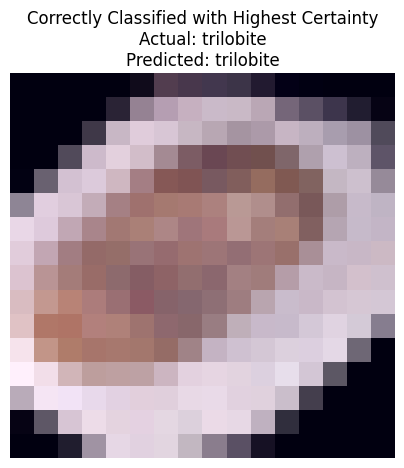

```
Acutal: trilobite
Predicted: trilobite
Probability of bonsai: 0.000068
Probability of brain: 0.000193
Probability of butterfly: 0.000063
Probability of hawksbill: 0.000005
Probability of kangaroo: 0.000002
Probability of trilobite: 0.999667
```

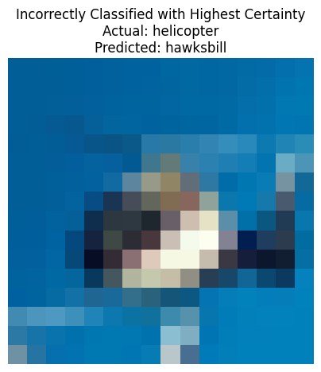

```
Acutal: helicopter
Predicted: hawksbill
Probability of Faces: 0.000131
Probability of Faces_easy: 0.000080
Probability of Leopards: 0.003623
Probability of Motorbikes: 0.000108
Probability of airplanes: 0.035067
Probability of bonsai: 0.003267
Probability of brain: 0.000318
Probability of buddha: 0.000350
Probability of butterfly: 0.002184
Probability of car_side: 0.005977
Probability of chandelier: 0.000325
Probability of grand_piano: 0.001970
Probability of hawksbill: 0.913229
Probability of helicopter: 0.009876
Probability of kangaroo: 0.018630
Probability of ketch: 0.000018
Probability of menorah: 0.000218
Probability of starfish: 0.002234
Probability of trilobite: 0.001313
Probability of watch: 0.001083
```

```python
best_model_names = ['best_model_batch_norm_True', 'best_model_batch_norm_False']

for model_name in best_model_names:
    print(f"Evaluating {model_name}")
    model, history, X_test_std, y_test, lb = load_model_and_history(path_name, model_name)
    df_report = plot_and_evaluate_model(model, history, X_test_std, y_test, lb)
    print(df_report)
    show_predictions(model, X_test_std, y_test, lb, correctly_classified_images=1, incorrectly_classified_images=1)
```

# Comparative Analysis of Neural Network Models with and without Batch Normalization

## 1. Overall Predictive Ability of the Models

### Model with Batch Normalization:

- Accuracy: 68.94%
- Precision and Recall varied across classes, showing better performance in classes like 'Faces_easy' and 'Motorbikes' but weaker in 'buddha' and 'butterfly'.

### Model without Batch Normalization:

- Accuracy: 66.59%
- Similarly, this model showed varying precision and recall across different classes, with notable performance in 'trilobite' and 'car_side' but lower scores in 'buddha' and 'kangaroo'.

### Conclusion:

- The model with batch normalization slightly outperforms the one without in overall accuracy. However, class-specific performance varies, indicating that one model may be more suited for certain classes than the other.

## 2. Impact of Batch Normalization on Overfitting and Underfitting

- The model with batch normalization shows signs of reduced overfitting compared to the model without it, as evidenced by the smoother learning curves and a more consistent gap between training and validation accuracy.

## 3. Learning Duration and Model Complexity

- Training time for the model with batch normalization was slightly longer (64.10 seconds) compared to the one without it (60.04 seconds). Both models have the same number of parameters (43,204).

## 4. Profitability of Batch Normalization

- The marginal increase in accuracy and the potential reduction in overfitting make the model with batch normalization slightly more preferable, although the increase in training time should be considered.

## 5. Learning Curve Shape

- The learning curve of the model with batch normalization is smoother, suggesting more stable learning. In contrast, the model without batch normalization shows more fluctuation in loss and accuracy, especially in the validation phase.

## 6. Recommendations for Improvement

- For classes where the model performs poorly, such as 'buddha' and 'butterfly', data augmentation or class-specific tuning could be beneficial.
- Further tuning of hyperparameters, including learning rate and batch size, could also be explored to enhance model performance.

### Best Model Selection

Given the overall metrics and the smoother learning curve, the model with batch normalization is slightly better. However, specific use cases, especially concerning class-specific performance, may influence the choice.

## Part 2 - Summary of Experimental Comparative Analysis

### Overview

Part 2 of the project involved an experimental comparative analysis to understand the impact of various factors on the performance of a Convolutional Neural Network (CNN). The focus was on exploring the effects of training set size, dropout rates, regularization, activation functions, and batch normalization.

```
Loading existing model...
```

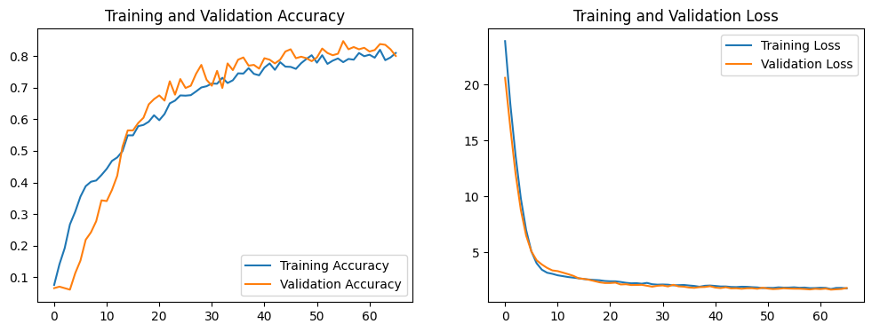

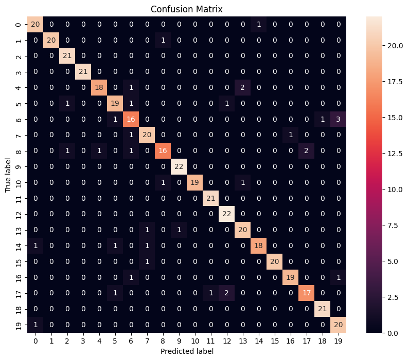

```
[[20  0  0  0  0  0  0  0  0  0  0  0  0  0  1  0  0  0  0  0]
 [ 0 20  0  0  0  0  0  0  1  0  0  0  0  0  0  0  0  0  0  0]
 [ 0  0 21  0  0  0  0  0  0  0  0  0  0  0  0  0  0  0  0  0]
 [ 0  0  0 21  0  0  0  0  0  0  0  0  0  0  0  0  0  0  0  0]
 [ 0  0  0  0 18  0  1  0  0  0  0  0  0  2  0  0  0  0  0  0]
 [ 0  0  1  0  0 19  1  0  0  0  0  0  1  0  0  0  0  0  0  0]
 [ 0  0  0  0  0  1 16  0  0  0  0  0  0  0  0  0  0  0  1  3]
 [ 0  0  0  0  0  0  1 20  0  0  0  0  0  0  0  0  1  0  0  0]
 [ 0  0  1  0  1  0  1  0 16  0  0  0  0  0  0  0  0  2  0  0]
 [ 0  0  0  0  0  0  0  0  0 22  0  0  0  0  0  0  0  0  0  0]
 [ 0  0  0  0  0  0  0  0  1  0 19  0  0  1  0  0  0  0  0  0]
 [ 0  0  0  0  0  0  0  0  0  0  0 21  0  0  0  0  0  0  0  0]
 [ 0  0  0  0  0  0  0  0  0  0  0  0 22  0  0  0  0  0  0  0]
 [ 0  0  0  0  0  0  0  1  0  1  0  0  0 20  0  0  0  0  0  0]
 [ 1  0  0  0  0  1  0  1  0  0  0  0  0  0 18  0  0  0  0  0]
 [ 0  0  0  0  0  0  0  1  0  0  0  0  0  0  0 20  0  0  0  0]
 [ 0  0  0  0  0  0  1  0  0  0  0  0  0  0  0  0 19  0  0  1]
 [ 0  0  0  0  0  1  0  0  0  0  0  1  2  0  0  0  0 17  0  0]
 [ 0  0  0  0  0  0  0  0  0  0  0  0  0  0  0  0  0  0 21  0]
 [ 1  0  0  0  0  0  0  0  0  0  0  0  0  0  0  0  0  0  0 20]]
              precision    recall  f1-score     support
Faces          0.909091  0.952381  0.930233   21.000000
Faces_easy     1.000000  0.952381  0.975610   21.000000
Leopards       0.913043  1.000000  0.954545   21.000000
Motorbikes     1.000000  1.000000  1.000000   21.000000
airplanes      0.947368  0.857143  0.900000   21.000000
bonsai         0.863636  0.863636  0.863636   22.000000
brain          0.761905  0.761905  0.761905   21.000000
buddha         0.869565  0.909091  0.888889   22.000000
butterfly      0.888889  0.761905  0.820513   21.000000
car_side       0.956522  1.000000  0.977778   22.000000
chandelier     1.000000  0.904762  0.950000   21.000000
grand_piano    0.954545  1.000000  0.976744   21.000000
hawksbill      0.880000  1.000000  0.936170   22.000000
helicopter     0.869565  0.909091  0.888889   22.000000
kangaroo       0.947368  0.857143  0.900000   21.000000
ketch          1.000000  0.952381  0.975610   21.000000
menorah        0.950000  0.904762  0.926829   21.000000
starfish       0.894737  0.809524  0.850000   21.000000
trilobite      0.954545  1.000000  0.976744   21.000000
watch          0.833333  0.952381  0.888889   21.000000
accuracy       0.917647  0.917647  0.917647    0.917647
macro avg      0.919706  0.917424  0.917149  425.000000
weighted avg   0.919331  0.917647  0.917078  425.000000
```

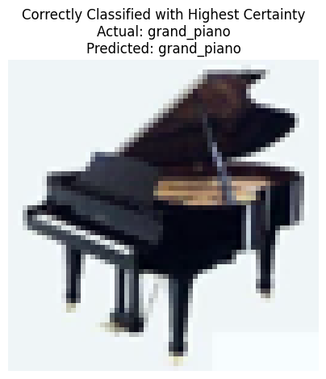

```
Acutal: grand_piano
Predicted: grand_piano
Probability of Faces: 0.000008
Probability of Faces_easy: 0.000001
Probability of bonsai: 0.000006
Probability of butterfly: 0.000004
Probability of chandelier: 0.000001
Probability of grand_piano: 0.999957
Probability of helicopter: 0.000012
Probability of starfish: 0.000001
Probability of watch: 0.000006
```

[figure not shown]

```
Acutal: bonsai
Predicted: Leopards
Probability of Faces: 0.000004
Probability of Leopards: 0.988394
Probability of airplanes: 0.000014
Probability of bonsai: 0.002227
Probability of brain: 0.005079
Probability of buddha: 0.000620
Probability of butterfly: 0.000336
Probability of car_side: 0.000005
Probability of chandelier: 0.000123
Probability of grand_piano: 0.000005
Probability of hawksbill: 0.000030
Probability of helicopter: 0.000247
Probability of kangaroo: 0.000926
Probability of ketch: 0.000002
Probability of menorah: 0.000672
Probability of starfish: 0.000753
Probability of trilobite: 0.000550
Probability of watch: 0.000011
```

```python
path_name = "optimized_models"
model_name = "model_2"
model, history, training_time, num_params, X_test, y_test, lb = create_and_train_model(model, X_train_std, y_train, X_test_std, y_test, lb, X_train_std.shape[1:], y_train.shape[1], path_name, model_name,
                                   dropout_rate=0.4,
                                   activation='relu',
                                   use_regularizer='l1_l2',
                                   use_batch_norm=True,
                                   pooling='max',
                                   use_global_pooling=False,
                                   verbose=True)

df_report = plot_and_evaluate_model(model, history, X_test_std, y_test, lb)
print(df_report)
show_predictions(model, X_test_std, y_test, lb, correctly_classified_images=1, incorrectly_classified_images=1)
```

# Summary and Analysis of Model_2 with Optimizations

## Model Configuration

- Model Name: `model_2`
- Key Parameters:
  - Dropout Rate: 0.4
  - Activation Function: ReLU
  - Regularizer: L1_L2
  - Batch Normalization: Enabled
  - Pooling Type: Max
  - Global Pooling: Disabled
- Training Time: 225.35 seconds
- Number of Parameters: 73,924

## Learning Curve Observations

- Loss showed a consistent downward trend, indicating effective learning.
- Both training and validation accuracies improved steadily, with validation accuracy closely following the training accuracy, suggesting good generalization.

## Predictions Analysis

- Correct Classification Example: 'grand_piano' class was predicted with high confidence (99.99%).
- Incorrect Classification Example: A 'bonsai' image was misclassified as 'Leopards' with a high probability of 98.83%.

## Conclusion

- `model_2` demonstrates strong predictive performance across most classes with a high overall accuracy.
- The use of dropout, batch normalization, and L1_L2 regularization contributed to the model's robustness against overfitting, as evidenced by the close match of training and validation accuracies.
- Some misclassifications indicate potential areas for improvement, possibly by fine-tuning class-specific features or further data augmentation.

### Next steps

- Investigate the features of misclassified instances to understand the underlying causes and adjust the model or data preprocessing accordingly.
- Explore further hyperparameter tuning or advanced techniques like transfer learning for classes with lower performance metrics.